# CITS 4009 Project

Dipta Datta GUPTA

2025-10-13

# 1. **Introduction**

In this project, we aim to explore the potential to predict whether a movie will generate high or low revenue based on its production country’s economic context. This exploration involves applying techniques from exploratory data analysis (EDA) and machine learning to model movie revenue. We will leverage R functions and visualization tools to clean, prepare, and analyze the data, ultimately building a classification model to forecast revenue outcomes.

The goal of this analysis is to assess the impact of various economic factors and movie-related features on box office performance. By the end of this project, we will have created a model that provides valuable insights into the key drivers of movie revenue generation and demonstrates the effectiveness of various classification methods in predicting high or low revenue outcomes.

Through a thorough investigation of the dataset, feature engineering, and evaluation of various classifiers, this project will provide an in-depth understanding of both the technical and contextual aspects of box office revenue prediction.

The libraries used in this project include:

- **`dplyr`** (v1.1.4): Used for efficient data manipulation, enabling us to filter, summarize, and transform the dataset.
- **`tidyr`** (v1.3.1): Used for reshaping the data into the appropriate format for analysis and visualization.
- **`ggplot2`** (v4.0.0): Used for creating compelling and insightful visualizations of the data.
- **`scales`** (v1.2.1): Used for formatting and adjusting the appearance of visualizations to enhance clarity and readability.
- **`caret`** (v7.0-1): Used for streamlining the machine learning workflow, from data pre-processing to model evaluation.
- **`pROC`** (v1.19.0.1): Used for evaluating classification models using ROC curves and calculating AUC (Area Under the Curve).
- **`rpart`** (v4.1.24): Used for building decision tree models to perform predictive analysis.
- **`randomForest` (v4.7-1.2)**: In this project, it was specifically utilized within the **rfe** (Recursive Feature Elimination) framework for feature selection. The `rffuncs` function from the `caret` package makes use of Random Forest for recursively eliminating less important features, improving model accuracy and performance by retaining only the most relevant predictors. The Random Forest algorithm helps mitigate overfitting and increases the robustness of the model through its aggregation of trees.
- **`FSelectorRcpp`** (v0.3.13): Used for identifying the most significant features in the dataset, improving model performance.
- **`lime`** (v0.5.3): Used for explaining machine learning model predictions, making the results interpretable and actionable.
- **`naniar`** (v.1.1.0): The library is used to manage missing values in a dataset. It offers tools to visualize missing data and generate summaries that can guide the decision-making process for imputing or removing missing values before further analysis.
- **`tinythemes`** (v0.0.4): Used for enhancing the visual appeal of `ggplot2` plots through custom themes.
- **`showtext`** (v0.9-4): Used for ensuring that textual elements are rendered properly, especially when using non-Latin characters or custom fonts.

By following these steps and using these libraries, we ensure that the analysis is **transparent**, **repeatable**, and adheres to **best practices in data science**. This approach guarantees that the insights gained are grounded in reproducible methodology, promoting confidence in the results and enabling further exploration by others.

## **Shiny App**

This project is accompanied by an interactive Shiny application that brings the analysis to life.

**Methodology** The Shiny app mirrors the full data-science pipeline—from exploratory analysis through feature selection, model training, evaluation, and deployment.

**Demo** A guided walkthrough of the app is available on YouTube: https://youtu.be/5-fc6ZMSyW0

# 2. **Dataset Exploration**

## 2.1 **Load Datasets**

We load three separate datasets into R for analysis: `GDP_2020_2024.csv`, `Population_2000_2024.csv`, and `Box_office_data(2000-2024).csv`. The `read.csv()` function is used to import each CSV file into R as data frames, which allows for subsequent data manipulation and analysis. The argument `check.names = FALSE` ensures that R does not modify any column names, preserving them as they appear in the original files. The `GDP_2020_2024.csv` file contains data on the Gross Domestic Product (GDP) of various countries over the period from 2020 to 2024, which will be used to assess the economic context of the movies’ production countries. The `Population_2000_2024.csv` file includes population data for the same period, providing insight into demographic factors that could influence movie performance. The `Box_office_data(2000-2024).csv` contains the box office revenue information for movies released between 2000 and 2024, which will be the target variable for predicting high or low revenue based on the economic context of the production country.

```r
gdp_data <- read.csv("GDP_2020_2024.csv", check.names = FALSE)
pop_data <- read.csv("Population_2000_2024.csv", check.names = FALSE)
box_office_data <- read.csv("Box_office_data(2000-2024).csv", check.names = FALSE)
```

For each dataset I print the first rows, structure, and targeted summaries to confirm column types and spot obvious anomalies or gaps-this guides the cleaning rules that follow.

## 2.2 **GDP Dataset Exploration**

```r
# Check first 6 rows
head(gdp_data)
```

```
##                  Country Name Country Code    Indicator Name Indicator Code
## 1                       Aruba          ABW GDP (current US$) NY.GDP.MKTP.CD
## 2 Africa Eastern and Southern          AFE GDP (current US$) NY.GDP.MKTP.CD
## 3                 Afghanistan          AFG GDP (current US$) NY.GDP.MKTP.CD
## 4  Africa Western and Central          AFW GDP (current US$) NY.GDP.MKTP.CD
## 5                      Angola          AGO GDP (current US$) NY.GDP.MKTP.CD
## 6                     Albania          ALB GDP (current US$) NY.GDP.MKTP.CD
##           2000         2001         2002         2003         2004         2005
## 1   1873452514   1896456983   1961843575   2044111732   2254830726   2360017318
## 2 287202000000 260992000000 267815000000 355716000000 442696000000 516661000000
## 3   3521418060   2813571754   3825701439   4520946819   5224896719   6203256539
## 4 142140000000 150058000000 179390000000 207755000000 258567000000 317096000000
## 5   9129594970   8936079118  15285592370  17812704586  23552057679  36970900884
## 6   3584570165   4059064033   4515003117   5801712040   7406645793   8256658250
##           2006         2007         2008         2009         2010         2011
```

[output cut: 27 more lines]

```r
# Check structure
str(gdp_data)
```

```
## 'data.frame':    266 obs. of  29 variables:
##  $ Country Name  : chr  "Aruba" "Africa Eastern and Southern" "Afghanistan" "Africa Western and Central" ...
##  $ Country Code  : chr  "ABW" "AFE" "AFG" "AFW" ...
##  $ Indicator Name: chr  "GDP (current US$)" "GDP (current US$)" "GDP (current US$)" "GDP (current US$)" ...
##  $ Indicator Code: chr  "NY.GDP.MKTP.CD" "NY.GDP.MKTP.CD" "NY.GDP.MKTP.CD" "NY.GDP.MKTP.CD" ...
##  $ 2000          : num  1.87e+09 2.87e+11 3.52e+09 1.42e+11 9.13e+09 ...
##  $ 2001          : num  1.90e+09 2.61e+11 2.81e+09 1.50e+11 8.94e+09 ...
##  $ 2002          : num  1.96e+09 2.68e+11 3.83e+09 1.79e+11 1.53e+10 ...
##  $ 2003          : num  2.04e+09 3.56e+11 4.52e+09 2.08e+11 1.78e+10 ...
##  $ 2004          : num  2.25e+09 4.43e+11 5.22e+09 2.59e+11 2.36e+10 ...
##  $ 2005          : num  2.36e+09 5.17e+11 6.20e+09 3.17e+11 3.70e+10 ...
##  $ 2006          : num  2.47e+09 5.80e+11 6.97e+09 4.03e+11 5.24e+10 ...
##  $ 2007          : num  2.68e+09 6.66e+11 9.75e+09 4.72e+11 6.53e+10 ...
##  $ 2008          : num  2.84e+09 7.14e+11 1.01e+10 5.75e+11 8.85e+10 ...
##  $ 2009          : num  2.55e+09 7.15e+11 1.24e+10 5.15e+11 7.03e+10 ...
##  $ 2010          : num  2.45e+09 8.49e+11 1.59e+10 6.06e+11 8.38e+10 ...
##  $ 2011          : num  2.64e+09 9.45e+11 1.78e+10 6.91e+11 1.12e+11 ...
##  $ 2012          : num  2.62e+09 9.53e+11 1.99e+10 7.48e+11 1.28e+11 ...
##  $ 2013          : num  2.73e+09 9.62e+11 2.01e+10 8.44e+11 1.32e+11 ...
##  $ 2014          : num  2.79e+09 9.79e+11 2.05e+10 9.04e+11 1.36e+11 ...
##  $ 2015          : num  2.96e+09 8.98e+11 1.91e+10 7.78e+11 9.05e+10 ...
##  $ 2016          : num  2.98e+09 8.29e+11 1.81e+10 7.00e+11 5.28e+10 ...
##  $ 2017          : num  3.09e+09 9.73e+11 1.88e+10 6.94e+11 7.37e+10 ...
##  $ 2018          : num  3.28e+09 1.01e+12 1.81e+10 7.78e+11 7.95e+10 ...
##  $ 2019          : num  3.40e+09 1.01e+12 1.88e+10 8.33e+11 7.09e+10 ...
##  $ 2020          : num  2.48e+09 9.33e+11 2.00e+10 7.97e+11 4.85e+10 ...
##  $ 2021          : num  2.93e+09 1.09e+12 1.43e+10 8.58e+11 6.65e+10 ...
##  $ 2022          : num  3.28e+09 1.19e+12 1.45e+10 8.94e+11 1.04e+11 ...
##  $ 2023          : num  3.65e+09 1.18e+12 1.72e+10 8.15e+11 8.49e+10 ...
##  $ 2024          : num  NA 1.29e+12 NA 6.70e+11 8.04e+10 ...
```

### Dataset Overview

The **GDP dataset** contains information about the **Gross Domestic Product (GDP)** of various countries and regions, spanning from **2000 to 2024**. The GDP is represented in **current US dollars**, and the data is organized by **country name**, **country code**, and **yearly GDP values**.

### Data Structure

The **GDP dataset** consists of **266 rows** and **29 columns**. Each row represents a different country or region, and each column corresponds to a specific year (2000 to 2024), with GDP values recorded for those years.

- **Type of Data**: The dataset contains both **numeric** (GDP values) and **categorical** (country name, country code) data.
- **Missing Values**: Several entries contain missing values (denoted as `NA`), which may require data cleaning or handling before analysis.

```r
# Summarize numeric columns
summary(gdp_data[, 5:ncol(gdp_data)])
```

```
##       2000                2001                2002
##  Min.   :1.507e+07   Min.   :1.396e+07   Min.   :1.684e+07
##  1st Qu.:3.035e+09   1st Qu.:2.814e+09   1st Qu.:3.034e+09
##  Median :1.439e+10   Median :1.418e+10   Median :1.459e+10
##  Mean   :9.869e+11   Mean   :9.800e+11   Mean   :1.003e+12
##  3rd Qu.:1.912e+11   3rd Qu.:1.918e+11   3rd Qu.:1.957e+11
##  Max.   :3.387e+13   Max.   :3.366e+13   Max.   :3.496e+13
##  NA's   :14          NA's   :13          NA's   :9
##       2003                2004                2005
##  Min.   :1.946e+07   Min.   :2.280e+07   Min.   :2.291e+07
##  1st Qu.:3.504e+09   1st Qu.:4.044e+09   1st Qu.:4.866e+09
##  Median :1.781e+10   Median :2.066e+10   Median :2.150e+10
##  Mean   :1.132e+12   Mean   :1.285e+12   Mean   :1.406e+12
##  3rd Qu.:2.186e+11   3rd Qu.:2.586e+11   3rd Qu.:3.100e+11
##  Max.   :3.921e+13   Max.   :4.418e+13   Max.   :4.785e+13
##  NA's   :9           NA's   :9           NA's   :9
##       2006                2007                2008
##  Min.   :2.410e+07   Min.   :2.307e+07   Min.   :3.187e+07
##  1st Qu.:5.107e+09   1st Qu.:5.831e+09   1st Qu.:6.603e+09
##  Median :2.400e+10   Median :3.069e+10   Median :3.414e+10
##  Mean   :1.537e+12   Mean   :1.759e+12   Mean   :1.955e+12
##  3rd Qu.:3.467e+11   3rd Qu.:4.128e+11   3rd Qu.:4.949e+11
##  Max.   :5.186e+13   Max.   :5.845e+13   Max.   :6.423e+13
##  NA's   :8           NA's   :8           NA's   :7
##       2009                2010                2011
##  Min.   :2.808e+07   Min.   :3.211e+07   Min.   :3.920e+07
##  1st Qu.:6.043e+09   1st Qu.:6.853e+09   1st Qu.:7.102e+09
##  Median :3.540e+10   Median :4.068e+10   Median :4.503e+10
##  Mean   :1.846e+12   Mean   :2.048e+12   Mean   :2.292e+12
##  3rd Qu.:4.291e+11   3rd Qu.:4.816e+11   3rd Qu.:5.296e+11
##  Max.   :6.091e+13   Max.   :6.672e+13   Max.   :7.421e+13
##  NA's   :5           NA's   :5           NA's   :4
##       2012                2013                2014
##  Min.   :3.935e+07   Min.   :3.862e+07   Min.   :3.876e+07
##  1st Qu.:8.587e+09   1st Qu.:8.523e+09   1st Qu.:9.113e+09
##  Median :4.456e+10   Median :4.957e+10   Median :5.143e+10
##  Mean   :2.369e+12   Mean   :2.456e+12   Mean   :2.522e+12
##  3rd Qu.:5.469e+11   3rd Qu.:5.325e+11   3rd Qu.:5.421e+11
##  Max.   :7.587e+13   Max.   :7.807e+13   Max.   :8.025e+13
##  NA's   :6           NA's   :6           NA's   :5
```

[output cut: 17 more lines]

```
##  Min.   :6.020e+07   Min.   :5.907e+07   Min.   :6.228e+07
##  1st Qu.:1.007e+10   1st Qu.:1.236e+10   1st Qu.:1.516e+10
##  Median :6.196e+10   Median :6.992e+10   Median :7.954e+10
##  Mean   :3.160e+12   Mean   :3.306e+12   Mean   :3.558e+12
##  3rd Qu.:6.372e+11   3rd Qu.:6.485e+11   3rd Qu.:8.347e+11
##  Max.   :9.837e+13   Max.   :1.024e+14   Max.   :1.070e+14
##  NA's   :9           NA's   :10          NA's   :18
##       2024
##  Min.   :1.604e+08
##  1st Qu.:1.947e+10
##  Median :9.320e+10
##  Mean   :3.965e+12
##  3rd Qu.:1.213e+12
##  Max.   :1.113e+14
##  NA's   :35
```

### Summary of Numeric Columns in GDP Dataset

The following summary provides a statistical overview of the numeric columns (GDP values from 2000 to 2024) in the **GDP dataset**.

**Key Statistics:** - **Min**: The minimum GDP value recorded for each year. - **1st Qu.**: The first quartile (25th percentile) of the GDP values for each year. - **Median**: The median (50th percentile) GDP value for each year. - **Mean**: The average GDP value for each year. - **3rd Qu.**: The third quartile (75th percentile) of the GDP values for each year. - **Max**: The maximum GDP value recorded for each year. - **NA’s**: The number of missing values for each year.

## 2.3 **Population Dataset Exploration**

```r
# Check first 6 rows
head(pop_data)
```

```
##             Name GENC Year Population Male Population Female Population
## 1        -> 2000        NA         --              --                --
## 2    Afghanistan   AF 2000 23,603,559      12,024,477        11,579,082
## 3        Albania   AL 2000  3,158,350       1,588,136         1,570,214
## 4        Algeria   DZ 2000 30,634,947      15,479,993        15,154,954
## 5 American Samoa   AS 2000     57,699          29,389            28,310
## 6        Andorra   AD 2000     65,099          34,013            31,086
##   Annual Growth Rate Rate of Natural Increase Population Density
## 1                 --                       --                 --
## 2              -0.79                     3.52               36.2
## 3              -1.02                      1.1              115.3
## 4                1.4                     1.46               12.9
## 5               0.09                     2.65              291.4
## 6              -0.12                     0.61              139.1
##   Natural Increase Total Fertility Rate Crude Birth Rate
```

[output cut: 20 more lines]

```r
# Check structure
str(pop_data)
```

```
## 'data.frame':    5700 obs. of  16 variables:
##  $ Name                                : chr  " -> 2000" "Afghanistan" "Albania" "Algeria" ...
##  $ GENC                                : chr  "" "AF" "AL" "DZ" ...
##  $ Year                                : int  NA 2000 2000 2000 2000 2000 2000 2000 2000 2000 ...
##  $ Population                          : chr  "--" "23,603,559" "3,158,350" "30,634,947" ...
##  $ Male Population                     : chr  "--" "12,024,477" "1,588,136" "15,479,993" ...
##  $ Female Population                   : chr  "--" "11,579,082" "1,570,214" "15,154,954" ...
##  $ Annual Growth Rate                  : chr  "--" "-0.79" "-1.02" "1.4" ...
##  $ Rate of Natural Increase            : chr  "--" "3.52" "1.1" "1.46" ...
##  $ Population Density                  : chr  "--" "36.2" "115.3" "12.9" ...
##  $ Natural Increase                    : chr  "--" "831,205" "34,849" "446,991" ...
##  $ Total Fertility Rate                : chr  "--" "7.4" "2.17" "2.37" ...
##  $ Crude Birth Rate                    : chr  "--" "46.7" "16.4" "19.2" ...
##  $ Life Expectancy at Birth, Both Sexes: chr  "--" "56.4" "74.7" "71.8" ...
##  $ Infant Mortality Rate, Both Sexes   : chr  "--" "87.6" "22.6" "38.5" ...
##  $ Crude Death Rate                    : chr  "--" "11.5" "5.4" "4.6" ...
##  $ Net Migration Rate                  : chr  "--" "-43.1" "-21.2" "-0.6" ...
```

### Dataset Overview

The **Population dataset** contains detailed demographic information for various countries and regions, spanning multiple years. The data includes various population metrics, such as male and female populations, population growth rates, fertility rates, life expectancy, and more.

### Key Columns:

- **Name**: This column lists the names of the countries or regions.
- **GENC**: The country code for each country or region.
- **Year**: The year for the population data entry.
- **Population**: The total population of the country or region.
- **Male Population**: The male population for each country or region.
- **Female Population**: The female population for each country or region.
- **Annual Growth Rate**: The annual growth rate of the population.
- **Rate of Natural Increase**: The rate at which the population is naturally increasing.
- **Population Density**: The population density, calculated as the number of people per unit area.
- **Natural Increase**: The difference between the birth rate and the death rate.
- **Total Fertility Rate**: The average number of children born to women over their lifetime.
- **Crude Birth Rate**: The number of live births per 1,000 people per year.
- **Life Expectancy at Birth, Both Sexes**: The expected number of years a newborn is expected to live.
- **Infant Mortality Rate, Both Sexes**: The number of infant deaths per 1,000 live births.
- **Crude Death Rate**: The number of deaths per 1,000 people per year.
- **Net Migration Rate**: The difference between the number of immigrants and emigrants in a given year.

### Data Structure

The **Population dataset** consists of **5,700 rows** and **16 columns**. Each row represents a different country’s population data for a specific year. The data spans multiple years, with several demographic indicators provided for each country and region.

- **Type of Data**: The dataset contains both **numeric** (e.g., population, fertility rate) and **categorical** (e.g., country name, country code) data.
- **Missing Values**: Several entries contain missing values (denoted as `"--"`), particularly in the earlier years (e.g., 2000), which may require data cleaning or handling before analysis.

### Data Type Issue:

All the numeric columns (e.g., **Population**, **Male Population**, **Female Population**, **Annual Growth Rate**) are currently represented as **character** types. To perform numeric analysis, these columns need to be converted to **numeric** data types. Special attention should be given to any non-numeric entries, such as **missing values** represented by `"--"`.

## 2.4 **Box Office Dataset Exploration**

```r
# Check first 6 rows
head(box_office_data)
```

```
##   Rank                  Release Group $Worldwide $Domestic Domestic %  $Foreign
## 1    1         Mission: Impossible II  546388108 215409889       39.4 330978219
## 2    2                      Gladiator  460583960 187705427       40.8 272878533
## 3    3                      Cast Away  429632142 233632142       54.4 196000000
## 4    4                What Women Want  374111707 182811707       48.9 191300000
## 5    5                       Dinosaur  349822765 137748063       39.4 212074702
## 6    6 How the Grinch Stole Christmas  345842198 260745620       75.4  85096578
##   Foreign % Year                       Genres   Rating Vote_Count
## 1      60.6 2000  Adventure, Action, Thriller 6.126/10       6741
## 2      59.2 2000     Action, Drama, Adventure 8.217/10      19032
## 3      45.6 2000             Adventure, Drama 7.663/10      11403
## 4      51.1 2000              Comedy, Romance  6.45/10       3944
## 5      60.6 2000 Animation, Family, Adventure 6.544/10       2530
## 6      24.6 2000      Family, Comedy, Fantasy   6.8/10       7591
##   Original_Language                     Production_Countries
## 1                en                 United States of America
## 2                en United Kingdom, United States of America
## 3                en                 United States of America
## 4                en United Kingdom, United States of America
## 5                en                 United States of America
## 6                en        Germany, United States of America
```

```r
# Check structure
str(box_office_data)
```

```
## 'data.frame':    5000 obs. of  13 variables:
##  $ Rank                : int  1 2 3 4 5 6 7 8 9 10 ...
##  $ Release Group       : chr  "Mission: Impossible II" "Gladiator" "Cast Away" "What Women Want" ...
##  $ $Worldwide          : num  5.46e+08 4.61e+08 4.30e+08 3.74e+08 3.50e+08 ...
##  $ $Domestic           : num  2.15e+08 1.88e+08 2.34e+08 1.83e+08 1.38e+08 ...
##  $ Domestic %          : num  39.4 40.8 54.4 48.9 39.4 75.4 50.3 55.6 53.1 53.3 ...
##  $ $Foreign            : num  3.31e+08 2.73e+08 1.96e+08 1.91e+08 2.12e+08 ...
##  $ Foreign %           : num  60.6 59.2 45.6 51.1 60.6 24.6 49.7 44.4 46.9 46.7 ...
##  $ Year                : int  2000 2000 2000 2000 2000 2000 2000 2000 2000 2000 ...
##  $ Genres              : chr  "Adventure, Action, Thriller" "Action, Drama, Adventure" "Adventure, Drama" "Comedy, Romance" ...
##  $ Rating              : chr  "6.126/10" "8.217/10" "7.663/10" "6.45/10" ...
##  $ Vote_Count          : num  6741 19032 11403 3944 2530 ...
##  $ Original_Language   : chr  "en" "en" "en" "en" ...
##  $ Production_Countries: chr  "United States of America" "United Kingdom, United States of America" "United States of America" "United Kingdom, United States of America" ...
```

### Dataset Overview

The **Box Office dataset** contains information about the performance of various movies in terms of worldwide, domestic, and foreign revenue. The dataset includes details such as movie rankings, release group, revenue, genre, ratings, vote counts, and more.

### Key Columns:

- **Rank**: The ranking of the movie based on box office revenue.
- **Release Group**: The title of the movie.
- **$Worldwide**: The total worldwide box office revenue for the movie in US dollars.
- **$Domestic**: The domestic box office revenue (within the country of production) in US dollars.
- **Domestic %**: The percentage of the total revenue that was generated domestically.
- **$Foreign**: The foreign box office revenue (outside the country of production) in US dollars.
- **Foreign %**: The percentage of the total revenue generated from foreign markets.
- **Year**: The year the movie was released.
- **Genres**: The genres associated with the movie.
- **Rating**: The movie’s rating, typically in the format of “X.XXX/10”.
- **Vote_Count**: The number of votes the movie received, likely from audience or critics.
- **Original_Language**: The primary language of the movie.
- **Production_Countries**: The countries where the movie was produced.

### Data Structure

The **Box Office dataset** consists of **5,000 rows** and **13 columns**. Each row represents a different movie, with detailed information about its revenue, genre, ratings, and other movie attributes.

- **Type of Data**: The dataset includes both **numeric** (e.g., revenue, vote count) and **categorical** (e.g., movie title, genre) data.
- **Missing Values**: The dataset seems to have no missing values for most columns, although some entries may contain missing or special values for certain attributes (e.g., `NA` or unknown genres).

```r
# Summarize numeric columns
summary(box_office_data[, c("$Worldwide", "$Domestic", "$Foreign", "Year", "Vote_Count")])
```

```
##    $Worldwide          $Domestic            $Foreign              Year
##  Min.   :1.666e+06   Min.   :        0   Min.   :0.000e+00   Min.   :2000
##  1st Qu.:2.466e+07   1st Qu.:    92752   1st Qu.:1.371e+07   1st Qu.:2006
##  Median :4.845e+07   Median : 17984212   Median :3.019e+07   Median :2012
##  Mean   :1.192e+08   Mean   : 44725233   Mean   :7.449e+07   Mean   :2012
##  3rd Qu.:1.198e+08   3rd Qu.: 53868472   3rd Qu.:7.212e+07   3rd Qu.:2018
##  Max.   :2.799e+09   Max.   :936662225   Max.   :1.994e+09   Max.   :2024
##
##    Vote_Count
##  Min.   :    0.0
##  1st Qu.:  205.2
##  Median : 1035.5
##  Mean   : 2531.6
##  3rd Qu.: 3065.0
##  Max.   :36753.0
##  NA's   :170
```

## 2.5 **Box Office Dataset: Summary of Numeric Columns**

The following summary provides an overview of the numeric columns in the **Box Office dataset**. The dataset includes values related to **movie revenue**, **year**, and **vote count**.

# 3. **Data Cleaning**

## 3.1 **Defining Helper Functions**

`clean_numeric`

The `clean_numeric` function is designed to clean a specific numeric column in a dataset by removing rows with missing (`NA`) or non-positive values. It accepts two parameters: `data`, the data frame to be cleaned, and `col_name`, the name of the column to be cleaned. The function first checks if the specified column exists in the dataset; if not, it stops with an error message. Then, it filters the dataset using the `dplyr` package’s `filter()` function to retain only rows where the values in the specified column are not `NA` and are greater than 0. The function calculates how many rows were removed due to missing or non-positive values and computes the percentage of dropped rows relative to the total number of rows. This information is printed to the console using `cat()`. In case of an error during this process, the function uses `tryCatch()` to handle the error gracefully and prints an error message without interrupting the execution. The cleaned dataset is returned as the output of the function.

### Explanation of the Function:

- **Input**:
  - `data`: The data frame that contains the numeric column to be cleaned.
  - `col_name`: The name of the column to be cleaned, provided as a string.
- **Process**:
  1. **Column Existence Check**: The function first checks if the specified column (`col_name`) exists in the `data` data frame. If the column is not found, an error is raised with a message: “Column not found in data frame”.
  2. **Row Filtering**:
     - The function removes rows where the specified column contains **NA** (missing) values or non-positive values (i.e., values that are less than or equal to zero). This is done using the `filter()` function from `dplyr`, which retains only rows where the column value is **greater than 0**.
  3. **Row Count and Percentage**:
     - After filtering, the function calculates how many rows were removed by comparing the number of rows before and after the filtering process.
     - The percentage of removed rows is then calculated and displayed to the user in the console using `cat()`.
  4. **Return Value**:
     - The cleaned dataset is returned, containing only rows where the specified column has valid, positive values.
- **Error Handling**:
  - If any error occurs during the process (e.g., invalid column name), the function uses `tryCatch()` to gracefully handle the error and print a relevant message without interrupting the rest of the program.

### Reasoning Behind the Function:

- **Why Remove NA and Non-Positive Values?**
  - **NA values**: Missing data can lead to inaccurate or incomplete analysis. Removing rows with missing values ensures that only complete data is used in calculations or models.
  - **Non-positive values**: In many cases, negative or zero values are not meaningful for certain variables. For instance, revenue, age, or vote count should always be positive numbers, and rows with non-positive values may distort analysis or models.
- **Why Display the Drop Percentage?**
  - Showing the percentage of removed rows helps provide transparency about how much data has been discarded, giving insight into the quality of the original data. If a significant portion of the data is removed, it may indicate that the dataset requires further cleaning or that the data collection process might have issues.

### Example Use Case:

cleaned_data <- clean_numeric(data = box_office_data, col_name = “$Worldwide”)

```r
# Source: OpenAI
# Model: GPT-5
clean_numeric <- function(data, col_name) {
  tryCatch({
    if (!col_name %in% colnames(data)) stop("Column not found in data frame")
    original_rows <- nrow(data)
    data <- data %>%
      filter(!is.na(.data[[col_name]]) & .data[[col_name]] > 0)
    removed_rows <- original_rows - nrow(data)
    drop_percent <- (removed_rows / original_rows) * 100
    cat(
      "Removed", removed_rows, "rows (", round(drop_percent, 2),
      "%) from", col_name, "due to NA or non-positive values\n"
    )
    data
  }, error = function(e) {
    message("Error in clean_numeric: ", e$message)
    data
  })
}
```

`check_drop_percentage`

The `check_drop_percentage` function is designed to summarize the changes in the number of rows in a dataset before and after cleaning. It calculates and reports the percentage of rows either **added** or **dropped**, providing an important summary of the data cleaning process. The function also includes a warning mechanism to notify users if more than 5% of the rows are dropped during the cleaning process.

### Explanation of the Function:

- **Input**:
  - `original_rows`: The number of rows in the dataset before any cleaning operations.
  - `new_rows`: The number of rows remaining in the dataset after cleaning.
  - `dataset_name`: A string representing the name of the dataset, used for labeling in the summary output.
- **Process**:
  1. **Calculate Row Change**:
     - The function calculates the difference between the original and cleaned row counts, stored in the variable `change`. This helps determine whether rows have been added or dropped during the cleaning process.
  2. **Added Rows Handling**:
     - If `change` is positive (i.e., more rows have been added), the function calculates the percentage of added rows by dividing the change by the original row count, then multiplying by 100 to get the percentage.
     - The function then prints a summary of the cleaning process, including the original and cleaned row counts, the number of added rows, and the percentage of added rows.
  3. **Dropped Rows Handling**:
     - If `change` is negative (i.e., rows have been dropped), the function calculates the percentage of dropped rows similarly by dividing the absolute value of the change by the original row count and multiplying by 100.
     - If more than 5% of the rows are dropped, the function raises a warning using `warning()`, indicating that more than 5% of the data has been removed.
     - A summary of the cleaning process is then printed, including the original and cleaned row counts, the number of dropped rows, and the percentage of dropped rows.
- **Output**:
  - The function prints a detailed summary of the cleaning process to the console, showing the number of original and cleaned rows, and the percentage of rows added or dropped. If more than 5% of the rows were dropped, a warning is raised to alert the user to the potential loss of data.

### Reasoning Behind the Function:

- **Why Track Added or Dropped Rows?**
  - Keeping track of how many rows were added or dropped provides transparency in the data cleaning process. This helps users assess the effectiveness and impact of the cleaning operations. If too many rows are dropped, it might suggest issues with data quality or cleaning criteria that need further review.
- **Why the 5% Threshold for Dropped Rows?**
  - A 5% threshold is commonly used in data cleaning to flag significant data loss. Dropping too many rows can compromise the integrity of the dataset, so it is important to alert the user if such a significant portion of data is lost. This threshold ensures that users can make informed decisions about whether further cleaning or adjustments are needed.

### Example Use Case:

check_drop_percentage(original_rows = 1000, new_rows = 950, dataset_name = “box_office_data”)

```r
# Source: OpenAI
# Model: GPT-5
check_drop_percentage <- function(original_rows, new_rows, dataset_name) {
  change <- new_rows - original_rows
  if (change > 0) {
    add_percent <- change / original_rows * 100
    cat(
      "--- ", dataset_name, " Cleaning Summary ---\n",
      "Original rows:", original_rows, "\n",
      "Cleaned rows:", new_rows, "\n",
      "Added rows:", change, " (", round(add_percent, 2), "%)\n\n",
      sep = ""
    )
  } else {
    drop_percent <- abs(change) / original_rows * 100
    if (drop_percent > 5) {
      warning(
        paste(dataset_name, "lost", round(drop_percent, 2),
              "% of rows (>5% threshold)")
      )
    }
    cat(
      "--- ", dataset_name, " Cleaning Summary ---\n",
      "Original rows:", original_rows, "\n",
      "Cleaned rows:", new_rows, "\n",
      "Dropped rows:", abs(change), " (", round(drop_percent, 2), "%)\n\n",
      sep = ""
    )
  }
}
```

`summarize_missingness`

### Explanation of the Function: `summarize_missingness`

The `summarize_missingness` function is designed to provide a comprehensive summary of missing values in a given dataset. It uses the **`naniar`** package to analyze and report the missingness of the dataset.

#### 1. **Function Definition**:

- `summarize_missingness <- function(df, label)`:
  - The function takes two arguments:
    - `df`: The dataset (data frame) for which missing values need to be summarized.
    - `label`: A label used in the printed summary to identify the dataset.

#### 2. **Summary of Dataset Dimensions**:

- `cat("\n--- Missingness summary:", label, "---\n")`:
  - This line prints the title of the summary, including the provided `label` to identify the dataset being analyzed.
- `cat("Total rows:", nrow(df), "\n")`:
  - Prints the total number of rows in the dataset.
- `cat("Total columns:", ncol(df), "\n")`:
  - Prints the total number of columns in the dataset.

#### 4. **Variable-Wise Missingness**:

- `miss_tbl <- miss_var_summary(df) %>% arrange(desc(pct_miss))`:
  - This line calculates the missingness for each variable using the `miss_var_summary` function and arranges the variables in descending order of the percentage of missing values (`pct_miss`).
- `print(miss_tbl)`:
  - Prints the summarized table of missing values by variable, showing the percentage of missing data for each variable.

#### Purpose of the Function:

This function helps to quickly assess the extent of missing data in a dataset, allowing for informed decisions about how to handle the missingness (e.g., imputation, deletion, etc.).

### Example Use Case:

summarize_missingness(pop_data, “Population (raw)”)

```r
summarize_missingness <- function(df, label) {
  cat("\n--- Missingness summary:", label, "---\n")
  cat("Total rows:", nrow(df), "\n")
  cat("Total columns:", ncol(df), "\n")
  cat("Total missing cells:", sum(naniar::n_miss(df)), "\n\n")

  miss_tbl <- miss_var_summary(df) %>% arrange(desc(pct_miss))
  print(miss_tbl)
}
```

`remove_invalid_values`

The `remove_invalid_values` function is designed to clean individual values in a vector (or column) by replacing any invalid values (represented as `"--"`) with **NA** (Not Available), which is a standard representation for missing data in R. This function ensures that any invalid placeholders (such as `"--"`) are properly handled during data cleaning, making the dataset ready for analysis.

#### Explanation of the Function:

- **Input**:
  - `x`: A vector or column from a data frame that contains the data to be cleaned. This could be a single numeric or character column.
- **Process**:
  - The function uses **`ifelse()`** to check each element in the vector `x`. If an element is equal to `"--"`, it is replaced with **NA**.
  - If the element is not `"--"`, it remains unchanged.

#### Reasoning Behind the Function:

- **Why Replace `"--"` with NA?**
  - In datasets, invalid or missing values are often represented by placeholders like `"--"`, `"NA"`, or `"?"`. These values cannot be used for analysis directly, as they are treated as character data.
  - Replacing `"--"` with **NA** standardizes the representation of missing data, allowing R’s built-in functions to handle them properly (e.g., for statistical calculations or plotting).
- **Why Use `ifelse()`?**
  - The **`ifelse()`** function is a vectorized operation, meaning it checks each element in the vector and applies the condition (`x == "--"`) efficiently without the need for a loop. This makes it fast and scalable for large datasets.

### Example Use Case:

cleaned_column <- remove_invalid_values(data$column_name)

```r
remove_invalid_values <- function(x) {
  ifelse(x == "--", NA, x)
}
```

## 3.2 **GDP Data Cleaning**

### Check for Missing Values:

The **`summarize_missingness`** function is used to check for missing values (NA) in the **GDP dataset**. This function provides the count of missing values for each column, which helps in understanding the extent of missing data.

```r
summarize_missingness(gdp_data, "GDP (raw)")
```

```
##
## --- Missingness summary: GDP (raw) ---
## Total rows: 266
## Total columns: 29
## Total missing cells: 237
##
## # A tibble: 29 × 3
##    variable n_miss pct_miss
##    <chr>     <int>    <num>
##  1 2024         35    13.2
##  2 2023         18     6.77
##  3 2000         14     5.26
##  4 2001         13     4.89
##  5 2022         10     3.76
##  6 2002          9     3.38
##  7 2003          9     3.38
##  8 2004          9     3.38
##  9 2005          9     3.38
## 10 2020          9     3.38
## # ℹ 19 more rows
```

### 3.2.1 GDP Data Cleaning Process

In this section, we clean the **GDP dataset** by addressing the following tasks:

1. **Save Original Row Count**:
   - The initial number of rows in the `gdp_data` dataset is saved into the variable `original_gdp_rows` for later comparison. This allows us to track how many rows were removed during the cleaning process.
2. **Remove Commas from GDP Values**:
   - The `mutate(across(...))` function is used to transform the GDP data across all columns from `2000` to `2024`. The `gsub()` function is applied to remove any commas in the GDP values (which are typically used as thousands separators). This ensures that all GDP values are treated as numeric, as commas would cause them to be read as text.
3. **Pivot the Data**:
   - The `pivot_longer()` function reshapes the data from a wide format (with one column for each year) to a long format. In the long format, each row represents a single country’s GDP for a specific year, with the columns “Year” and “GDP”. This is useful for making the data more manageable and easier to analyze over time.
4. **Convert “Year” to Integer**:
   - The `mutate()` function is used again to convert the `Year` column to an integer type, ensuring it is stored as a numeric value rather than a character. This allows for proper numerical analysis when performing operations involving the year.
5. **Replace Full Country Names**:
   - The `gsub()` function is used to standardize the country names. Specifically, it replaces “United States of America” with “United States” in the `Country Name` column. This ensures consistency in naming and prevents discrepancies caused by different representations of the same country.
6. **Rearrange Columns**:
   - The `select()` function is used to reorder the columns, moving `Country_Name`, `Year`, and `GDP` to the front, followed by any other columns. This makes the dataset easier to work with and ensures that the most important columns are at the beginning.
7. **Clean the “GDP” Column**:
   - The `clean_numeric()` function is applied to the `GDP` column to remove any rows where GDP values are missing (`NA`) or non-positive. This ensures that only valid, positive GDP values are retained for further analysis.

#### Reasoning Behind the Process:

- **Why Remove Commas in GDP Values?**
  - GDP values often include commas to separate thousands for readability. However, commas are not valid in numeric data types, so they must be removed to ensure that the values can be treated as numbers for analysis.
- **Why Pivot the Data?**
  - Pivoting the data from wide to long format is essential because it makes it easier to analyze trends over time. In long format, the data is organized by year, with each row representing a country’s GDP for a specific year, which is more efficient for time series analysis and visualization.
- **Why Standardize Country Names?**
  - Standardizing country names ensures consistency across the dataset. Without this step, discrepancies in country naming (e.g., “United States of America” vs. “United States”) could lead to duplicates or confusion when aggregating or analyzing data.
- **Why Clean the “GDP” Column?**
  - Removing non-positive or missing GDP values is essential for maintaining the quality and integrity of the dataset. Non-positive GDP values or missing data would distort analysis, so it is important to only include valid entries in the dataset.

```r
original_gdp_rows <- nrow(gdp_data) # Save original for comparison
# GDP Data Cleaning
gdp_data_long <- gdp_data %>%
  mutate(across(`2000`:`2024`, ~ as.numeric(gsub(",", "", .)))) %>%
  pivot_longer(
    cols = `2000`:`2024`,
    names_to = "Year",
    values_to = "GDP"
  ) %>%
  mutate(
    Year = as.integer(Year),
    Country_Name = gsub(
      "United States of America", "United States", `Country Name`
    )
  ) %>%
  select(Country_Name, Year, GDP, everything()) %>%
  clean_numeric("GDP")
```

```
## Removed 237 rows ( 3.56 %) from GDP due to NA or non-positive values
```

#### Summary of GDP Data Cleaning:

After cleaning, I show the head, structure, and simple row counts so we can verify the updated schema and understand how many observations remain versus the original pull.

```r
# Check cleaned data
print(head(gdp_data_long))
```

```
## # A tibble: 6 × 7
##   Country_Name  Year        GDP `Country Name` `Country Code` `Indicator Name`
##   <chr>        <int>      <dbl> <chr>          <chr>          <chr>
## 1 Aruba         2000 1873452514 Aruba          ABW            GDP (current US$)
## 2 Aruba         2001 1896456983 Aruba          ABW            GDP (current US$)
## 3 Aruba         2002 1961843575 Aruba          ABW            GDP (current US$)
## 4 Aruba         2003 2044111732 Aruba          ABW            GDP (current US$)
## 5 Aruba         2004 2254830726 Aruba          ABW            GDP (current US$)
## 6 Aruba         2005 2360017318 Aruba          ABW            GDP (current US$)
## # ℹ 1 more variable: `Indicator Code` <chr>
```

```r
print(str(gdp_data_long))
```

```
## tibble [6,413 × 7] (S3: tbl_df/tbl/data.frame)
##  $ Country_Name  : chr [1:6413] "Aruba" "Aruba" "Aruba" "Aruba" ...
##  $ Year          : int [1:6413] 2000 2001 2002 2003 2004 2005 2006 2007 2008 2009 ...
##  $ GDP           : num [1:6413] 1.87e+09 1.90e+09 1.96e+09 2.04e+09 2.25e+09 ...
##  $ Country Name  : chr [1:6413] "Aruba" "Aruba" "Aruba" "Aruba" ...
##  $ Country Code  : chr [1:6413] "ABW" "ABW" "ABW" "ABW" ...
##  $ Indicator Name: chr [1:6413] "GDP (current US$)" "GDP (current US$)" "GDP (current US$)" "GDP (current US$)" ...
##  $ Indicator Code: chr [1:6413] "NY.GDP.MKTP.CD" "NY.GDP.MKTP.CD" "NY.GDP.MKTP.CD" "NY.GDP.MKTP.CD" ...
## NULL
```

```r
# Check Missing Values After Cleaning
colSums(is.na(gdp_data_long))
```

```
##   Country_Name           Year            GDP   Country Name   Country Code
##              0              0              0              0              0
## Indicator Name Indicator Code
##              0              0
```

```r
# Check row changes
check_drop_percentage(original_gdp_rows * length(2000:2024),
                      nrow(gdp_data_long), "GDP")
```

```
## --- GDP Cleaning Summary ---
## Original rows:6650
## Cleaned rows:6413
## Dropped rows:237 (3.56%)
```

After completing these steps, the GDP dataset is now in a clean, long format with the cleaning steps outlined above successfully applied.

The cleaned GDP dataset is now ready for futher analysis.

## 3.2 **Population Data Cleaning**

### Checking for Missing Values:

The **`summarize_missingness`** function is used to check for missing values (NA) in each column of the **Population dataset**. The result shows the number of missing values in each column.

```r
summarize_missingness(pop_data, "Population (raw)")
```

```
##
## --- Missingness summary: Population (raw) ---
## Total rows: 5700
## Total columns: 16
## Total missing cells: 50
##
## # A tibble: 16 × 3
##    variable                             n_miss pct_miss
##    <chr>                                 <int>    <num>
##  1 GENC                                     25    0.439
##  2 Year                                     25    0.439
##  3 Name                                      0    0
##  4 Population                                0    0
##  5 Male Population                           0    0
##  6 Female Population                         0    0
##  7 Annual Growth Rate                        0    0
##  8 Rate of Natural Increase                  0    0
##  9 Population Density                        0    0
## 10 Natural Increase                          0    0
## 11 Total Fertility Rate                      0    0
## 12 Crude Birth Rate                          0    0
## 13 Life Expectancy at Birth, Both Sexes      0    0
## 14 Infant Mortality Rate, Both Sexes         0    0
## 15 Crude Death Rate                          0    0
## 16 Net Migration Rate                        0    0
```

### 3.2.1 Population Data Cleaning Process:

#### Reasoning Behind the Process:

- **Why Remove Invalid Values?**
  - Invalid values, such as non-numeric entries or values outside of expected ranges, can cause issues in analysis or modeling. Removing these values ensures the dataset is clean and consistent, allowing for accurate insights.
- **Why Remove Commas and Convert to Numeric?**
  - Population and demographic data may include commas for thousands separation, but commas are not compatible with numeric data types. Removing them ensures that the values are treated as numbers and can be used in calculations, such as population growth rates or demographic analysis.
- **Why Convert the Year to Integer?**
  - Ensuring that the `Year` column is of integer type allows it to be used effectively in time series analysis and filtering. This ensures that the data is correctly interpreted when analyzing trends over time.
- **Why Filter for Missing or Invalid Values?**
  - Filtering out rows with missing or invalid values (such as missing `GENC` or non-positive population) helps ensure that only valid data is included in the analysis, which increases the reliability of the results.

```r
# Save original row count
original_pop_rows <- nrow(pop_data)
# Population Data Cleaning
pop_data_clean <- pop_data %>%
  mutate(across(everything(), remove_invalid_values)) %>%
  mutate(
    Population = as.numeric(gsub(",", "", Population)),
    `Male Population` = as.numeric(gsub(",", "", `Male Population`)),
    `Female Population` = as.numeric(gsub(",", "", `Female Population`)),
    `Annual Growth Rate` = as.numeric(`Annual Growth Rate`),
    `Life Expectancy at Birth, Both Sexes` =
      as.numeric(`Life Expectancy at Birth, Both Sexes`),
    Year = as.integer(Year),
    Name = gsub("United States of America", "United States", Name)
  ) %>%
  filter(!is.na(GENC)) %>%
  filter(!is.na(Population) & Population > 0 & Year >= 2000 & Year <= 2024)
```

### Summary of Population Data Cleaning

```r
# Check cleaned data
print(head(pop_data))
```

```
##             Name GENC Year Population Male Population Female Population
## 1        -> 2000        NA         --              --                --
## 2    Afghanistan   AF 2000 23,603,559      12,024,477        11,579,082
## 3        Albania   AL 2000  3,158,350       1,588,136         1,570,214
## 4        Algeria   DZ 2000 30,634,947      15,479,993        15,154,954
## 5 American Samoa   AS 2000     57,699          29,389            28,310
## 6        Andorra   AD 2000     65,099          34,013            31,086
##   Annual Growth Rate Rate of Natural Increase Population Density
## 1                 --                       --                 --
## 2              -0.79                     3.52               36.2
## 3              -1.02                      1.1              115.3
## 4                1.4                     1.46               12.9
## 5               0.09                     2.65              291.4
## 6              -0.12                     0.61              139.1
##   Natural Increase Total Fertility Rate Crude Birth Rate
```

[output cut: 20 more lines]

```r
print(str(pop_data))
```

```
## 'data.frame':    5700 obs. of  16 variables:
##  $ Name                                : chr  " -> 2000" "Afghanistan" "Albania" "Algeria" ...
##  $ GENC                                : chr  "" "AF" "AL" "DZ" ...
##  $ Year                                : int  NA 2000 2000 2000 2000 2000 2000 2000 2000 2000 ...
##  $ Population                          : chr  "--" "23,603,559" "3,158,350" "30,634,947" ...
##  $ Male Population                     : chr  "--" "12,024,477" "1,588,136" "15,479,993" ...
##  $ Female Population                   : chr  "--" "11,579,082" "1,570,214" "15,154,954" ...
##  $ Annual Growth Rate                  : chr  "--" "-0.79" "-1.02" "1.4" ...
##  $ Rate of Natural Increase            : chr  "--" "3.52" "1.1" "1.46" ...
##  $ Population Density                  : chr  "--" "36.2" "115.3" "12.9" ...
##  $ Natural Increase                    : chr  "--" "831,205" "34,849" "446,991" ...
##  $ Total Fertility Rate                : chr  "--" "7.4" "2.17" "2.37" ...
##  $ Crude Birth Rate                    : chr  "--" "46.7" "16.4" "19.2" ...
##  $ Life Expectancy at Birth, Both Sexes: chr  "--" "56.4" "74.7" "71.8" ...
##  $ Infant Mortality Rate, Both Sexes   : chr  "--" "87.6" "22.6" "38.5" ...
##  $ Crude Death Rate                    : chr  "--" "11.5" "5.4" "4.6" ...
##  $ Net Migration Rate                  : chr  "--" "-43.1" "-21.2" "-0.6" ...
## NULL
```

```r
# Check Missing Values After Cleaning
colSums(is.na(pop_data))
```

```
##                                 Name                                 GENC
##                                    0                                   25
##                                 Year                           Population
##                                   25                                    0
##                      Male Population                    Female Population
##                                    0                                    0
##                   Annual Growth Rate             Rate of Natural Increase
##                                    0                                    0
##                   Population Density                     Natural Increase
##                                    0                                    0
##                 Total Fertility Rate                     Crude Birth Rate
##                                    0                                    0
## Life Expectancy at Birth, Both Sexes    Infant Mortality Rate, Both Sexes
##                                    0                                    0
##                     Crude Death Rate                   Net Migration Rate
##                                    0                                    0
```

```r
# Check row changes
check_drop_percentage(original_pop_rows, nrow(pop_data), "Population")
```

```
## --- Population Cleaning Summary ---
## Original rows:5700
## Cleaned rows:5700
## Dropped rows:0 (0%)
```

## 3.3 **Box Office Data Cleaning**

### Checking for Missing Values:

The `summarize_missingness` function is used to check for missing values (NA) in each column of the **Box Office dataset**. The result shows the number of missing values in each column.

```r
summarize_missingness(box_office_data, "Box Office (raw)")
```

```
##
## --- Missingness summary: Box Office (raw) ---
## Total rows: 5000
## Total columns: 13
## Total missing cells: 170
##
## # A tibble: 13 × 3
##    variable             n_miss pct_miss
##    <chr>                 <int>    <num>
##  1 Vote_Count              170      3.4
##  2 Rank                      0      0
##  3 Release Group             0      0
##  4 $Worldwide                0      0
##  5 $Domestic                 0      0
##  6 Domestic %                0      0
##  7 $Foreign                  0      0
##  8 Foreign %                 0      0
##  9 Year                      0      0
## 10 Genres                    0      0
## 11 Rating                    0      0
## 12 Original_Language         0      0
## 13 Production_Countries      0      0
```

### 3.3.1 Box Office Data Cleaning Process

1. **Save Original Row Count**:
   - The original number of rows in the `box_office_data` dataset is saved into the variable `original_box_rows`. This allows for comparison of the dataset before and after cleaning to track how many rows were removed or modified.
2. **Cleaning the `$Worldwide`, `$Domestic`, and `$Foreign` Columns**:
   - The `mutate()` function is used to clean the `"$Worldwide"`, `"$Domestic"`, and `"$Foreign"` columns:
     - **Remove Commas**: The `gsub()` function removes any commas in the values, as commas are typically used to separate thousands and would prevent the values from being treated as numeric.
     - **Replace `--` with NA**: The `gsub()` function replaces occurrences of `--` (which likely represent missing or unknown values) with `NA`, ensuring that these entries are recognized as missing data.
     - **Convert to Numeric**: After the commas are removed and `--` is replaced with `NA`, the values are converted to numeric data types using `as.numeric()`. This allows for proper numerical operations such as summation, averaging, and comparison.
3. **Cleaning the `Rating` Column**:
   - The `Rating` column is cleaned similarly:
     - **Remove “/10”**: The `gsub()` function removes the `"/10"` suffix from the rating values, leaving only the numeric part.
     - **Replace `--` with NA**: As with the other columns, any occurrences of `--` are replaced with `NA` to denote missing data.
     - **Convert to Numeric**: The cleaned values are then converted to numeric data types.
4. **Cleaning the `Vote_Count` Column**:
   - The `Vote_Count` column is cleaned in a similar manner:
     - **Remove Commas**: The `gsub()` function removes any commas from the vote count values, ensuring they can be treated as numbers.
     - **Replace `--` with NA**: The `gsub()` function replaces any occurrences of `--` with `NA` to represent missing data.
     - **Convert to Numeric**: The values are then converted to numeric data types for further analysis.
5. **Filter Out Rows with Missing or Invalid `$Worldwide` Values**:
   - The `filter()` function is used to remove rows where the `"$Worldwide"` column has missing values (`NA`) or non-positive values (i.e., values less than or equal to zero). This ensures that only valid data (with positive worldwide revenue) is retained for analysis.
6. **Return Cleaned Dataset**:
   - The cleaned dataset, `box_office_numeric`, now contains valid, numeric values in the relevant columns, ready for further analysis or modeling.

#### Reasoning Behind the Process:

- **Why Remove Commas and Replace `--` with NA?**
  - Commas in numeric columns (such as revenue or vote count) prevent the values from being recognized as numeric. Removing commas ensures the values can be treated as numbers for analysis. Replacing `--` with `NA` ensures that missing or unknown data is properly handled and does not interfere with the analysis.
- **Why Convert Rating and Vote Count to Numeric?**
  - Rating and vote count should be numeric for any mathematical operations, such as calculating average ratings or aggregating votes. Converting these columns to numeric ensures they can be used in statistical analysis or machine learning models.
- **Why Filter Out Invalid `$Worldwide` Values?**
  - The `$Worldwide` column is key to the analysis of box office performance. It is important to ensure that only valid rows with positive revenue values are included, as rows with missing or zero/negative values would distort the results.

```r
# Save original row count
original_box_rows <- nrow(box_office_data)
# Box Office Data Cleaning
box_office_numeric <- box_office_data %>%
  mutate(
    `$Worldwide` = as.numeric(gsub(",", "", gsub("--", NA, `$Worldwide`))),
    `$Domestic` = as.numeric(gsub(",", "", gsub("--", NA, `$Domestic`))),
    `$Foreign` = as.numeric(gsub(",", "", gsub("--", NA, `$Foreign`))),
    Rating = as.numeric(gsub("/10", "", gsub("--", NA, Rating))),
    Vote_Count = as.numeric(gsub(",", "", gsub("--", NA, Vote_Count)))
  ) %>%
  filter(!is.na(`$Worldwide`) & `$Worldwide` > 0)
```

### Explanation of the Box Office Data Cleaning Process (Continued):

1. **Splitting the `Production_Countries` Column**:
   - The `mutate()` function is used to transform the `Production_Countries` column:
     - **Split by Comma**: The `strsplit()` function splits the values in the `Production_Countries` column by “,”, creating a list where each entry contains the names of the production countries for a given movie. For example, a movie produced in both the “United States” and “Canada” would have these two country names separated into two list elements.
2. **Standardizing Country Names**:
   - After splitting the values, the `lapply()` function is used to apply a transformation to each list of production countries:
     - **Replace “United States of America” with “United States”**: The `gsub()` function is used to standardize country names by replacing “United States of America” with “United States”. This ensures consistency in the naming of countries across the dataset, preventing discrepancies when analyzing or aggregating data by country.
3. **Unnesting the List of Countries**:
   - The `unnest()` function from `tidyr` is then used to “unnest” the list of countries created by `strsplit()`. This function converts the list of production countries into individual rows, where each row represents one production country for a particular movie. This transformation makes the data easier to analyze, as each movie’s production country will now appear as a separate row.
4. **Return Cleaned Dataset**:
   - The resulting dataset, `box_office_clean`, contains individual rows for each production country of a movie, with standardized country names, ready for further analysis, such as aggregating box office revenue by country or exploring the relationships between countries and movie success.

#### Reasoning Behind the Process:

- **Why Split the `Production_Countries` Column?**
  - The `Production_Countries` column likely contains multiple country names for movies produced in more than one country. By splitting this column, each country is treated as a separate entity, allowing for more detailed analysis, such as examining how different countries contribute to box office revenue or how collaboration between countries affects movie performance.
- **Why Standardize Country Names?**
  - Standardizing country names ensures consistency across the dataset. Without this step, country names like “United States of America” and “United States” would be treated as different entries, causing issues when performing aggregations or comparisons. This helps in accurate data aggregation and analysis.
- **Why Unnest the List of Countries?**
  - Unnesting the list of countries makes the dataset “longer” but more granular. Each movie will now have a separate row for each production country, which is crucial for performing analyses where the country-specific performance of movies is important (e.g., analyzing the global reach of movies).

We then check the row changes before unnesting the `Production_Countries` column to ensure we understand how many rows were dropped during the cleaning process.

```r
# Check row changes before unnesting
check_drop_percentage(original_box_rows, nrow(box_office_numeric), "Box Office")
```

```
## --- Box Office Cleaning Summary ---
## Original rows:5000
## Cleaned rows:5000
## Dropped rows:0 (0%)
```

```r
box_office_clean <- box_office_numeric %>%
  mutate(
    Production_Countries = strsplit(Production_Countries, ", "),
    Production_Countries = lapply(
      Production_Countries,
      function(x) gsub("United States of America", "United States", x)
    )
  ) %>%
  unnest(Production_Countries)
```

#### Summary of Box Office Data Cleaning

After cleaning, I show the head, structure, and simple row counts so we can verify the updated schema and understand how many observations remain versus the original pull.

```r
# Check cleaned data
print(head(box_office_clean))
```

```
## # A tibble: 6 × 13
##    Rank `Release Group`        `$Worldwide` `$Domestic` `Domestic %` `$Foreign`
##   <int> <chr>                         <dbl>       <dbl>        <dbl>      <dbl>
## 1     1 Mission: Impossible II    546388108   215409889         39.4  330978219
## 2     2 Gladiator                 460583960   187705427         40.8  272878533
## 3     2 Gladiator                 460583960   187705427         40.8  272878533
## 4     3 Cast Away                 429632142   233632142         54.4  196000000
## 5     4 What Women Want           374111707   182811707         48.9  191300000
## 6     4 What Women Want           374111707   182811707         48.9  191300000
## # ℹ 7 more variables: `Foreign %` <dbl>, Year <int>, Genres <chr>,
## #   Rating <dbl>, Vote_Count <dbl>, Original_Language <chr>,
## #   Production_Countries <chr>
```

```r
print(str(box_office_clean))
```

```
## tibble [7,212 × 13] (S3: tbl_df/tbl/data.frame)
##  $ Rank                : int [1:7212] 1 2 2 3 4 4 5 6 6 7 ...
##  $ Release Group       : chr [1:7212] "Mission: Impossible II" "Gladiator" "Gladiator" "Cast Away" ...
##  $ $Worldwide          : num [1:7212] 5.46e+08 4.61e+08 4.61e+08 4.30e+08 3.74e+08 ...
##  $ $Domestic           : num [1:7212] 2.15e+08 1.88e+08 1.88e+08 2.34e+08 1.83e+08 ...
##  $ Domestic %          : num [1:7212] 39.4 40.8 40.8 54.4 48.9 48.9 39.4 75.4 75.4 50.3 ...
##  $ $Foreign            : num [1:7212] 3.31e+08 2.73e+08 2.73e+08 1.96e+08 1.91e+08 ...
##  $ Foreign %           : num [1:7212] 60.6 59.2 59.2 45.6 51.1 51.1 60.6 24.6 24.6 49.7 ...
##  $ Year                : int [1:7212] 2000 2000 2000 2000 2000 2000 2000 2000 2000 2000 ...
##  $ Genres              : chr [1:7212] "Adventure, Action, Thriller" "Action, Drama, Adventure" "Action, Drama, Adventure" "Adventure, Drama" ...
##  $ Rating              : num [1:7212] 6.13 8.22 8.22 7.66 6.45 ...
##  $ Vote_Count          : num [1:7212] 6741 19032 19032 11403 3944 ...
##  $ Original_Language   : chr [1:7212] "en" "en" "en" "en" ...
##  $ Production_Countries: chr [1:7212] "United States" "United Kingdom" "United States" "United States" ...
## NULL
```

```r
# Check Missing Values After Cleaning
print(colSums(is.na(box_office_clean)))
```

[output not shown]

After performing these steps, the **Box Office dataset** is now clean and transformed as per the outlined process.

The dataset is now ready for further analysis.

# 4. **Visualizations**

## 4.1 **Define Visualization Theme**

To ensure consistency across all visualizations, I define a custom theme using the tinythemes package. This theme sets a clean and minimal aesthetic, with specific adjustments to text sizes, colors, and grid lines to enhance readability and visual appeal. And, I make use of the ‘Roboto Condensed’ font from Google Fonts for a modern look.

```r
font_add_google("Roboto Condensed", "Roboto Condensed")
showtext_auto()
base_font <- "Roboto Condensed"
theme_set(
  theme_ipsum_rc(
    base_family = base_font,
    base_size = 24,
    plot_title_size = 28,
    plot_title_face = "bold",
    subtitle_size = 22,
    axis_text_size = 18,
    axis_title_size = 14,
    caption_size = 16,
    grid_col = "#cccccc",
    axis_col = "#cccccc",
    axis = FALSE,
    ticks = FALSE
  ) +
    theme(
      plot.title = element_text(hjust = 0),
      plot.subtitle = element_text(hjust = 0),
      legend.position = "bottom"
    )
)
```

## 4.2 **Single-Variable Plots**

I use single variable plots to explore the distributions of key numeric fields across the datasets. Logarithmic x-axes help manage the wide ranges in GDP, population, and box office revenue, while histograms reveal skewness, modes, and outliers.

### 4.2.1 **Distribution of Worldwide Box Office Revenue**

Visualizes the distribution of worldwide box office revenue from 2000 to 2024, using a log scale on the x-axis for better comparison across movies with varying earnings. The bars are filled in blue with black outlines, and the chart includes titles and axis labels in USD format. I utilize 30 bins, with clear titles, subtitles, and axis labels, effectively showing box office revenue distributions.

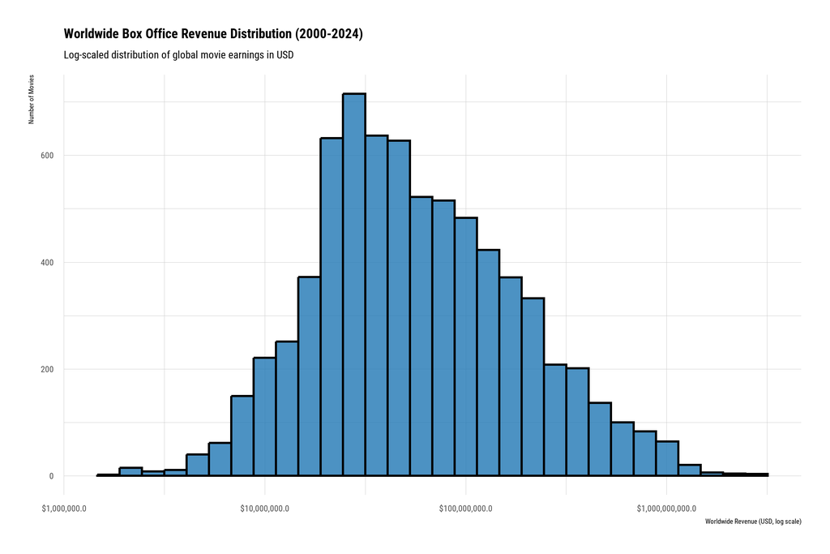

```r
ggplot(box_office_clean, aes(x = `$Worldwide`)) +
  geom_histogram(bins = 30, fill = "#1F77B4", colour = "black", alpha = 0.8) +
  scale_x_log10(labels = dollar_format(prefix = "$", big.mark = ",", accuracy = 0.1)) +
  scale_y_continuous(labels = comma) +
  labs(
    title = "Worldwide Box Office Revenue Distribution (2000-2024)",
    subtitle = "Log-scaled distribution of global movie earnings in USD",
    x = "Worldwide Revenue (USD, log scale)",
    y = "Number of Movies"
  )
```

#### Explanation of the Visualization: Worldwide Box Office Revenue Distribution (2000-2024)

1. **X-Axis (Worldwide Revenue in USD)**:
   - The x-axis represents the worldwide revenue generated by movies, with a **logarithmic scale** applied. Each step on the scale represents a tenfold increase in revenue (e.g., $1,000,000 to $10,000,000, $10,000,000 to $100,000,000, etc.).
   - **Logarithmic scaling** is used to handle the highly skewed distribution of box office revenue, making it easier to observe both the lower and higher ends of the spectrum in a single view.
2. **Y-Axis (Number of Movies)**:
   - The y-axis shows the **number of movies** in each revenue bin. This indicates how many movies fall within each specific revenue range.
3. **Shape of the Distribution**:
   - The histogram is **right-skewed**, meaning that most movies have relatively low earnings, and only a few movies generate high revenues. This is a common pattern in box office data, where a large number of films have modest earnings, but only a small number of blockbusters make significantly more money.
4. **Key Observations**:
   - The **peak of the histogram** lies between **$10 million and $100 million**, which suggests that most movies fall within this revenue range.
   - There is a **gradual decline** in the number of movies as the revenue increases. Beyond $100 million in revenue, the number of movies decreases sharply.
   - A small number of movies make over **$1 billion**, but these high-earning movies are outliers and constitute a very small proportion of the overall distribution.
   - The **logarithmic scale** allows better visualization of both small and large earnings by spreading out the data points across the graph, ensuring that the low-revenue movies are not compressed at the bottom.
5. **Purpose of the Log-Scale**:
   - The log scale is essential because box office revenue data is highly skewed, with many movies earning relatively little and a few earning significantly more. Without a log scale, the chart would be dominated by the lower end of the revenue distribution, making it hard to visualize the few movies that earn millions or billions in global box office revenue.
6. **Context**:
   - This distribution provides insight into how box office earnings are distributed across movies. It shows that most movies earn modest amounts, while only a small number of blockbuster films achieve very high revenues. The log-scale visualization is key to understanding the disparity between high-earning films and the large majority of lower-earning ones.

#### **Overall Insights**:

- The histogram offers a clear view of the global box office landscape from 2000 to 2024. It shows that while a significant portion of films earn moderate revenues, only a very small fraction of movies achieve the high earnings seen in the multi-million and billion-dollar ranges. This distribution highlights the rarity and impact of blockbuster movies in the global film industry.

### 4.2.2 **Distribution of Worldwide GDP (2000-2024)**

Visualizes the global GDP distribution across countries for the same period, also using a log scale for GDP values, with green bars and similar formatting for labels. I utilize 30 bins, with clear titles, subtitles, and axis labels, effectively showing GDP distribution.

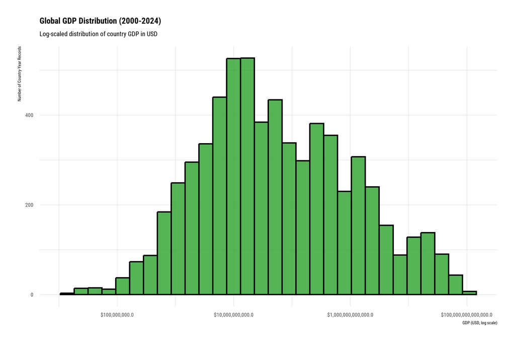

```r
ggplot(gdp_data_long, aes(x = GDP)) +
  geom_histogram(bins = 30, fill = "#2CA02C", colour = "black", alpha = 0.8) +
  scale_x_log10(labels = dollar_format(prefix = "$", big.mark = ",", accuracy = 0.1)) +
  labs(
    title = "Global GDP Distribution (2000-2024)",
    subtitle = "Log-scaled distribution of country GDP in USD",
    x = "GDP (USD, log scale)",
    y = "Number of Country-Year Records"
  )
```

#### **Overall Insights**:

- The histogram provides a clear picture of the global GDP distribution from 2000 to 2024. Most countries have moderate GDPs, but a few large economies drive the higher end of the distribution. The log scale allows for a more balanced and insightful view of global economic data, making it easier to compare countries at both the lower and higher ends of the GDP spectrum.

### 4.2.3 **Distribution of Population (2000-2024)**

Visualizes the population distribution across countries from 2000 to 2024, using a log scale for population values, with purple bars and similar formatting for labels. I utilize 30 bins, with clear titles, subtitles, and axis labels, effectively showing population distribution.

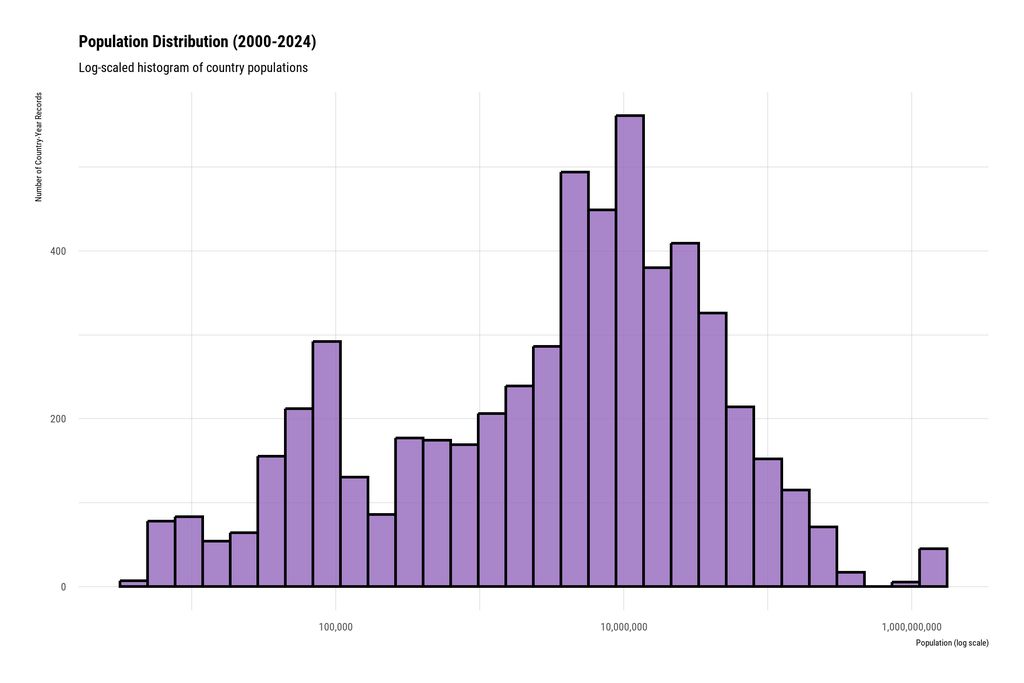

```r
pop_data_clean %>%
  filter(!is.na(Population), Population > 0) %>%
  ggplot(aes(x = Population)) +
  geom_histogram(bins = 30, fill = "#9467BD", colour = "black", alpha = 0.8) +
  scale_x_log10(labels = comma_format()) +
  scale_y_continuous(labels = comma_format()) +
  labs(
    title = "Population Distribution (2000-2024)",
    subtitle = "Log-scaled histogram of country populations",
    x = "Population (log scale)",
    y = "Number of Country-Year Records"
  )
```

#### **Overall Insights**:

- The histogram offers a clear view of the population distribution for countries worldwide from 2000 to 2024. Most countries fall within the middle population range, with very few countries at the extremes. The log-scale transformation enhances the readability and comparison of countries with both small and large populations.

## 4.3 **Multi-Variable Plots**

I use multi variable plots to explore how different data points relate to one another. Scatter plots reveal correlations and clusters, while boxplots and bar charts summarise distributions across categorical segments. Time series plots show trends and seasonality over time.

### 4.3.1 **Data Preparation and Merging for Multi-Variable Analysis**

`box_office_agg`

```r
box_office_agg <- box_office_clean %>%
  group_by(Year, Production_Countries) %>%
  summarise(
    Total_Revenue = sum(`$Worldwide`, na.rm = TRUE),
    Avg_Rating = mean(Rating, na.rm = TRUE),
    Avg_Vote_Count = mean(Vote_Count, na.rm = TRUE),
    Movie_Count = n(),
    .groups = "drop"
  ) %>%
  rename(Country_Name = Production_Countries)
```

#### Explanation for `box_office_agg` Data Preparation:

1. **Grouping the Data by Year and Production Countries**:
   - The `group_by()` function is used to group the `box_office_clean` dataset by **Year** and **Production_Countries**. This allows the data to be aggregated by both the year of release and the production countries involved in each movie, making it suitable for multi-variable analysis.
2. **Summarizing the Data**:
   - The `summarise()` function is used to create summary statistics for each group (i.e., each combination of year and production country). The following variables are calculated:
     - **Total_Revenue**: The total worldwide revenue for each country-year group, calculated using `sum()` on the `"$Worldwide"` column, with `na.rm = TRUE` to remove any missing values.
     - **Avg_Rating**: The average rating for movies in each group, calculated using `mean()` on the `Rating` column, excluding missing values with `na.rm = TRUE`.
     - **Avg_Vote_Count**: The average vote count for each group, calculated similarly using `mean()` on the `Vote_Count` column.
     - **Movie_Count**: The total number of movies in each group, calculated using `n()`, which counts the number of entries in each group.
   - The `.groups = "drop"` argument is used to remove the grouping after summarizing, returning a data frame that is no longer grouped by Year and Production_Countries.
3. **Renaming the `Production_Countries` Column**:
   - The `rename()` function is used to rename the `Production_Countries` column to `Country_Name`, making the column name more descriptive and easier to use in further analysis.
4. **Result**:
   - The resulting `box_office_agg` data frame contains aggregated data for each country-year combination, including the total revenue, average rating, average vote count, and the number of movies for each group. This prepared data can now be used for multi-variable analysis and visualization.

#### Reasoning Behind the Process:

- **Why Group by Year and Production Countries?**
  - Grouping by both year and production countries allows us to examine how the box office performance and movie characteristics (such as rating and vote count) vary over time and across different countries. This is essential for multi-variable analysis, where the relationship between multiple factors (like year, revenue, ratings, etc.) can be explored.
- **Why Use Summarization?**
  - Summarizing the data helps condense the information by calculating meaningful statistics for each group, making it easier to analyze trends over time and across countries. It also helps reduce the complexity of the dataset, focusing on key metrics like total revenue, average rating, and movie count.
- **Why Rename `Production_Countries` to `Country_Name`?**
  - Renaming the column makes it more intuitive and consistent for future analysis, as “Country_Name” is a clearer and more standardized label than “Production_Countries.”

`analysis_country`

```r
analysis_country <- box_office_agg %>%
  inner_join(gdp_data_long %>% select(Country_Name, Year, GDP),
             by = c("Country_Name", "Year")) %>%
  inner_join(
    pop_data_clean %>% select(
      Name, Year, Population, `Male Population`, `Female Population`,
      `Annual Growth Rate`, `Life Expectancy at Birth, Both Sexes`
    ),
    by = c("Country_Name" = "Name", "Year")
  ) %>%
  # Population-derived columns provide the demographic context requested in the brief
  mutate(
    Revenue_per_Capita = Total_Revenue / Population,
    GDP_per_Capita = GDP / Population,
    Male_Female_Ratio = `Male Population` / `Female Population`
  ) %>%
  distinct()
```

#### Explanation for `analysis_country` Data Preparation:

1. **Merging Box Office Data with GDP Data**:
   - The `inner_join()` function is used to merge the `box_office_agg` dataset with the `gdp_data_long` dataset. The merge is performed using two common columns: **Country_Name** and **Year**. This allows the GDP data for each country and year to be added to the aggregated box office data. The `select()` function ensures that only the relevant columns (`Country_Name`, `Year`, and `GDP`) are kept from the GDP dataset for the join.
2. **Merging with Population Data**:
   - Another `inner_join()` is applied to merge the resulting dataset with the `pop_data_clean` dataset, linking by **Country_Name** (from the box office and GDP data) and **Name** (from the population data) for the **Year**. The `select()` function is again used to retain only the relevant population columns: `Name`, `Year`, `Population`, `Male Population`, `Female Population`, `Annual Growth Rate`, and `Life Expectancy at Birth, Both Sexes`. This adds demographic context to the dataset, such as the population and sex distribution.
3. **Creating New Variables for Analysis**:
   - The `mutate()` function is used to create new variables that provide deeper insights into the relationship between box office revenue, GDP, and population:
     - **Revenue_per_Capita**: This is calculated by dividing the total revenue by the population, providing insight into how much revenue is generated per person in each country-year combination.
     - **GDP_per_Capita**: This is calculated by dividing GDP by the population, offering a per-person measure of economic activity.
     - **Male_Female_Ratio**: This is calculated by dividing the male population by the female population, providing a demographic ratio that can be useful for analyzing the gender balance in different countries.
4. **Ensuring Uniqueness of Rows**:
   - The `distinct()` function is used to ensure that the resulting dataset contains only unique rows. This is important to eliminate duplicate country-year entries that could have been introduced during the merging process.
5. **Result**:
   - The resulting `analysis_country` dataset contains merged data from box office, GDP, and population sources, along with new derived variables that facilitate multi-variable analysis. The dataset is now ready for further exploration, such as analyzing the relationship between GDP, population, and box office revenue across different countries and years.

#### Reasoning Behind the Process:

- **Why Use `inner_join()` for Merging?**
  - `inner_join()` is used to combine datasets on common columns (e.g., `Country_Name` and `Year`), ensuring that only records with matching values in both datasets are kept. This approach helps focus the analysis on the country-year combinations that have both box office and demographic/economic data available.
- **Why Create Derived Variables?**
  - The new variables like `Revenue_per_Capita` and `GDP_per_Capita` allow for more insightful comparisons by normalizing the box office revenue and GDP data with respect to the population. This helps to account for differences in country size. The **Male_Female_Ratio** provides additional demographic context, which might influence factors like movie consumption or box office performance.
- **Why Use `distinct()`?**
  - The `distinct()` function ensures that there are no duplicate records in the final dataset. Since the joins can sometimes result in multiple rows for the same country-year combination, using `distinct()` helps clean the dataset and keep only one record per combination.

`movie_vis_df`

```r
# Source: OpenAI
# Model: GPT-5
movie_vis_df <- box_office_clean %>%
  left_join(
    gdp_data_long %>%
      select(Country_Name, Year, GDP),
    by = c("Production_Countries" = "Country_Name", "Year")
  ) %>%
  left_join(
    pop_data_clean %>%
      select(
        Name, Year, Population,
        `Male Population`, `Female Population`,
        `Annual Growth Rate`
      ),
    by = c("Production_Countries" = "Name", "Year")
  ) %>%
  filter(GDP > 0, `$Worldwide` > 0, Population > 0) %>%
  mutate(
    relative_revenue = `$Worldwide` / GDP,
    High_Revenue = factor(
      if_else(relative_revenue > median(relative_revenue, na.rm = TRUE),
              "High", "Low"),
      levels = c("Low", "High")
    )
  ) %>%
  select(
    Movie = `Release Group`,
    Production_Countries,
    Year,
    Worldwide = `$Worldwide`,
    GDP,
    Population,
    High_Revenue
  )
```

### 4.3.2 Explanation for `movie_vis_df` Data Preparation

1. **Merging Box Office Data with GDP Data**:
   - The `left_join()` function is used to merge the `box_office_clean` dataset with the `gdp_data_long` dataset. The join is performed on two columns: **Production_Countries** (from the `box_office_clean` dataset) and **Country_Name** (from the `gdp_data_long` dataset), and also by matching **Year**. The `select()` function ensures that only the relevant columns — `Country_Name`, `Year`, and `GDP` — are included in the merge.
2. **Merging with Population Data**:
   - Another `left_join()` is applied to merge the resulting dataset with the `pop_data_clean` dataset, linking by **Production_Countries** (from the box office and GDP data) and **Name** (from the population data) for the **Year**. The `select()` function retains the necessary columns from the population data, such as `Name`, `Year`, `Population`, `Male Population`, `Female Population`, and `Annual Growth Rate`.
3. **Filtering the Data**:
   - The `filter()` function is used to remove rows where **GDP**, **Worldwide revenue**, or **Population** is less than or equal to zero, ensuring only valid records are included in the analysis.
4. **Calculating Relative Revenue**:
   - The `mutate()` function creates a new variable called **relative_revenue**, which is calculated by dividing the movie’s worldwide revenue (`$Worldwide`) by the country’s GDP. This provides a measure of the relative contribution of a movie’s revenue compared to the country’s economic size.
5. **Classifying High vs Low Revenue**:
   - The `High_Revenue` variable is created using the `if_else()` function, where movies with a relative revenue greater than the median relative revenue are classified as “High” revenue, and those below the median as “Low” revenue. The `factor()` function is used to label these categories with levels `"Low"` and `"High"`, making it easier to analyze the distribution of high and low revenue movies.
6. **Selecting Relevant Columns**:
   - The `select()` function is used to choose the final columns for the `movie_vis_df` dataset, including:
     - `Movie`: Renamed from `Release Group`
     - `Production_Countries`
     - `Year`
     - `Worldwide` (box office revenue)
     - `GDP`
     - `Population`
     - `High_Revenue` (classification of revenue as “High” or “Low”)
7. **Result**:
   - The resulting `movie_vis_df` dataset contains the final variables for analysis: the movie’s release group, production countries, year, worldwide revenue, GDP, population, and a classification of whether the movie’s revenue is high or low relative to the country’s GDP.

### 4.3.3 **Scatter Plot for Movie Revenue vs. GDP by Revenue Class**

To visualize the relationship between a movie’s worldwide box office revenue and the GDP of its production country, I create a scatter plot. Each point represents an individual film, with the x-axis showing the country’s GDP and the y-axis showing the movie’s worldwide revenue. The points are coloured based on whether the movie is classified as “High” or “Low” revenue relative to the country’s GDP. Logarithmic scales are applied to both axes to manage the wide ranges in GDP and revenue.

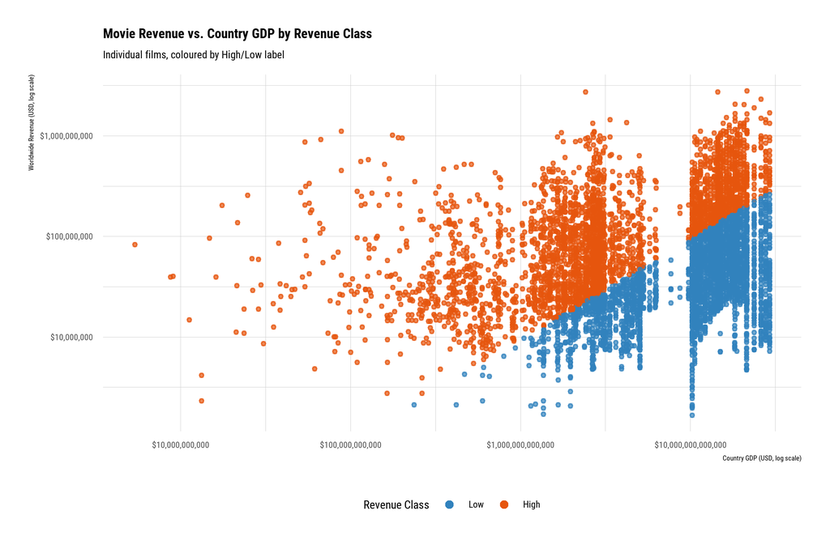

```r
ggplot(movie_vis_df, aes(x = GDP, y = Worldwide, colour = High_Revenue)) +
  geom_point(alpha = 0.7, size = 1.5) +
  scale_x_log10(labels = dollar_format()) +
  scale_y_log10(labels = dollar_format()) +
  scale_colour_manual(values = c("Low" = "#3182bd", "High" = "#e6550d")) +
  labs(
    title = "Movie Revenue vs. Country GDP by Revenue Class",
    subtitle = "Individual films, coloured by High/Low label",
    x = "Country GDP (USD, log scale)",
    y = "Worldwide Revenue (USD, log scale)",
    colour = "Revenue Class"
  ) +
  guides(colour = guide_legend(override.aes = list(alpha = 1, size = 3)))
```

#### **Overall Insights**:

- The scatter plot clearly shows that there is a strong relationship between a country’s GDP and the worldwide revenue of its movies. Movies from countries with higher GDP tend to have higher worldwide earnings, but there are exceptions, with some low-revenue movies emerging from countries with higher GDP and vice versa. The log scale helps to highlight these relationships and outliers in a more interpretable way.

### 4.3.4 **Scatter Plot for Revenue per Capita vs. Total Movie Revenue**

To examine how a country’s wealth on a per-person basis relates to its total movie revenue, I create a scatter plot with Revenue per Capita on the x-axis and Total Movie Revenue on the y-axis. Each point represents a country-year aggregate, and a red trend line indicates the overall correlation. Logarithmic scales are applied to both axes to manage the wide ranges in revenue per capita and total revenue.

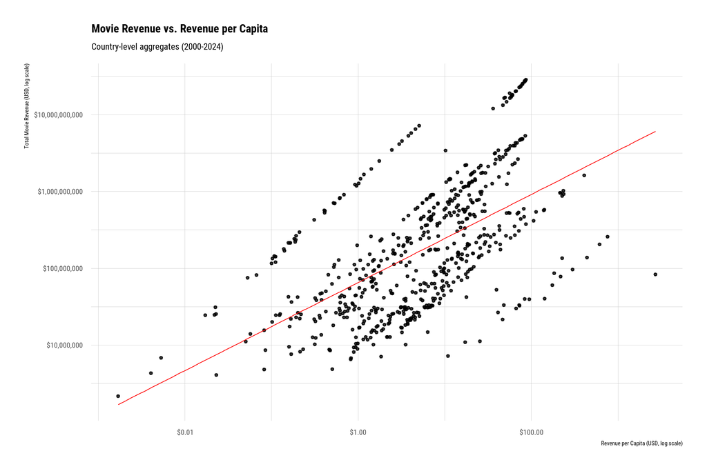

```r
analysis_country %>%
  ggplot(aes(x = Revenue_per_Capita, y = Total_Revenue)) +
  geom_point(alpha = 0.75, size = 1) +
  geom_smooth(method = "lm", se = FALSE, colour = "red", size = 0.5) +
  scale_x_log10(labels = dollar_format()) +
  scale_y_log10(labels = dollar_format()) +
  labs(
    title = "Movie Revenue vs. Revenue per Capita",
    subtitle = "Country-level aggregates (2000-2024)",
    x = "Revenue per Capita (USD, log scale)",
    y = "Total Movie Revenue (USD, log scale)"
  )
```

#### Explanation of the Visualization: Movie Revenue vs. Revenue per Capita

1. **X-Axis (Revenue per Capita in USD)**:
   - The x-axis represents the **Revenue per Capita** in USD, using a **logarithmic scale**. This scale is applied to handle the wide range of revenue per capita values, making it easier to interpret the data, particularly for countries with very low or very high revenue per capita.
2. **Y-Axis (Total Movie Revenue in USD)**:
   - The y-axis represents the **Total Movie Revenue** in USD, also using a **logarithmic scale**. The log scale helps manage the broad range of movie revenue, ensuring that both low and high-revenue movies can be effectively visualized in the same plot.
3. **Data Points (Country-Level Aggregates)**:
   - Each dot on the scatter plot represents a **country-year aggregate**, showing the total movie revenue for a specific country, and the corresponding **revenue per capita** for that country over the period from 2000 to 2024. The plot aggregates movie revenue and revenue per capita at the country level.
4. **Red Trend Line**:
   - A **red line** is plotted, indicating the general trend in the data. This line suggests a **positive correlation** between movie revenue and revenue per capita: as a country’s revenue per capita increases, the total movie revenue tends to increase as well. This relationship is reflected by the upward slope of the trend line.
5. **Key Observations**:
   - There is a **strong positive correlation** between revenue per capita and total movie revenue. Countries with higher revenue per capita tend to have higher total movie revenues, which makes sense as wealthier countries are more likely to produce and consume movies.
   - However, **there are exceptions**, with some countries having high revenue per capita but relatively low total movie revenues. This suggests that while individual wealth might play a role, other factors like population size, movie production, and international market access also influence total movie revenue.
   - The **logarithmic scaling** for both axes ensures that both the low and high values are clearly visible, and the relationship between the two variables is easier to analyze.
6. **Purpose of the Log-Scale**:
   - The log scale on both axes allows for the visualization of a wide range of values without the plot becoming too compressed or skewed by extreme outliers. The use of log scales ensures that trends are visible across both low and high ranges of revenue per capita and total revenue.
7. **Context**:
   - This scatter plot helps to explore the relationship between a country’s **economic wealth (revenue per capita)** and its **movie industry success (total revenue)**. It provides insights into how economic factors, like individual wealth, influence the financial performance of movies on a country-wide scale.

#### **Overall Insights**:

To explore how film earnings vary with national economic size, I segment countries into GDP brackets and plot boxplots of worldwide box office revenue within each band. The log-scaled y-axis reveals that while median revenues rise with GDP, the spread remains wide at all levels.

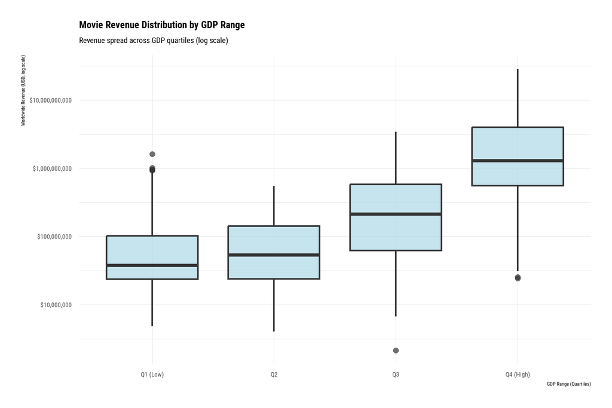

```r
analysis_country %>%
  mutate(
    GDP_Range = cut(
      GDP,
      breaks = quantile(GDP, probs = seq(0, 1, 0.25), na.rm = TRUE),
      labels = c("Q1 (Low)", "Q2", "Q3", "Q4 (High)"),
      include.lowest = TRUE
    )
  ) %>%
  ggplot(aes(x = GDP_Range, y = Total_Revenue)) +
  geom_boxplot(fill = "lightblue", alpha = 0.7) +
  scale_y_log10(labels = dollar_format()) +
  labs(
    title = "Movie Revenue Distribution by GDP Range",
    subtitle = "Revenue spread across GDP quartiles (log scale)",
    x = "GDP Range (Quartiles)",
    y = "Worldwide Revenue (USD, log scale)"
  )
```

### 4.3.6 **Bar Plot of High vs. Low Revenue Movies by Country GDP**

To further dissect the GDP-Revenue relationship, I classify movies as “High” or “Low” revenue based on whether their worldwide earnings exceed the median. Then, I tally how many high- and low-revenue films each country produced, segmented by GDP quartiles.

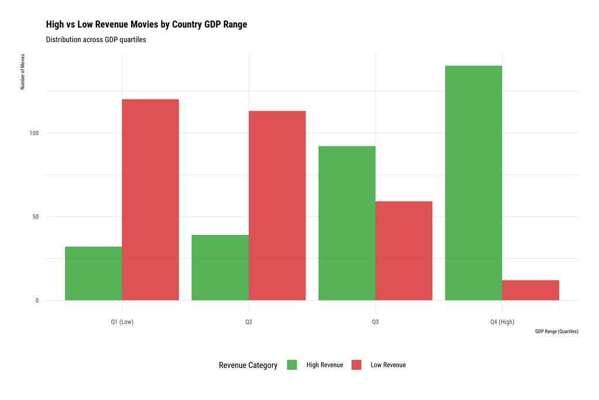

```r
analysis_country %>%
  mutate(
    GDP_Range = cut(
      GDP,
      breaks = quantile(GDP, probs = seq(0, 1, 0.25), na.rm = TRUE),
      labels = c("Q1 (Low)", "Q2", "Q3", "Q4 (High)"),
      include.lowest = TRUE
    ),
    Revenue_Category = if_else(
      Total_Revenue > median(Total_Revenue, na.rm = TRUE),
      "High Revenue", "Low Revenue"
    )
  ) %>%
  group_by(GDP_Range, Revenue_Category) %>%
  summarise(Count = n(), .groups = "drop") %>%
  ggplot(aes(x = GDP_Range, y = Count, fill = Revenue_Category)) +
  geom_col(position = "dodge", alpha = 0.8) +
  scale_fill_manual(values = c("High Revenue" = "#2CA02C", "Low Revenue" = "#D62728")) +
  labs(
    title = "High vs Low Revenue Movies by Country GDP Range",
    subtitle = "Distribution across GDP quartiles",
    x = "GDP Range (Quartiles)",
    y = "Number of Movies",
    fill = "Revenue Category"
  )
```

#### Explanation of the Visualization: High vs Low Revenue Movies by Country GDP Range

**Overall Insights**: - The visualization effectively demonstrates that **high GDP countries** (Q4) have a **larger proportion of high-revenue movies** compared to low GDP countries (Q1), which mostly have **low-revenue movies**. This trend suggests that higher economic prosperity provides better conditions for movie production and global consumption, allowing for higher box office earnings.

### 4.3.7 **Scatter Plot of Worldwide Movie Revenue vs. Population**

To explore how population size relates to total movie revenue, I create a scatter plot with Population on the x-axis and Total Movie Revenue on the y-axis. Each point represents a country-year observation, coloured by GDP quartile to add economic context. Logarithmic scales are applied to both axes to manage the wide ranges in population and revenue.

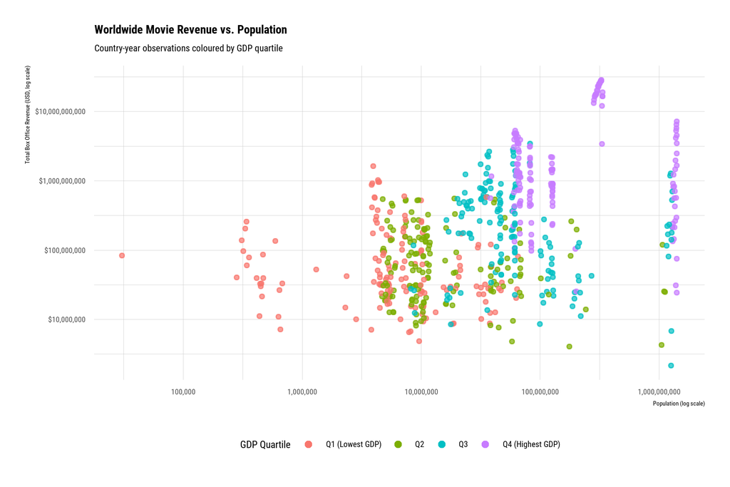

```r
analysis_country %>%
  mutate(
    GDP_Quartile = cut(
      GDP,
      breaks = quantile(GDP, probs = seq(0, 1, 0.25), na.rm = TRUE),
      include.lowest = TRUE,
      labels = c("Q1 (Lowest GDP)", "Q2", "Q3", "Q4 (Highest GDP)")
    )
  ) %>%
  drop_na(Population, Total_Revenue, GDP_Quartile) %>%
  ggplot(aes(x = Population, y = Total_Revenue, colour = GDP_Quartile)) +
  geom_point(alpha = 0.7, size = 2) +
  scale_x_log10(labels = comma_format()) +
  scale_y_log10(labels = dollar_format()) +
  labs(
    title = "Worldwide Movie Revenue vs. Population",
    subtitle = "Country-year observations coloured by GDP quartile",
    x = "Population (log scale)",
    y = "Total Box Office Revenue (USD, log scale)",
    colour = "GDP Quartile"
  ) +
  guides(colour = guide_legend(override.aes = list(alpha = 1, size = 3)))
```

#### Explanation of the Visualization: Worldwide Movie Revenue vs. Population

**Overall Insights**: - The plot demonstrates a **clear trend** where **countries with higher GDP and larger populations (Q4 - purple dots)** tend to generate higher movie revenues, while **low GDP countries (Q1 - red dots)** show a much lower range of movie revenue. The log scale ensures that the data points are spread out effectively, making it easier to visualize the varying relationships between movie revenue, population, and economic size across countries.

### 4.3.8 **Time Series Plot of Movie Revenue vs. GDP (USA)**

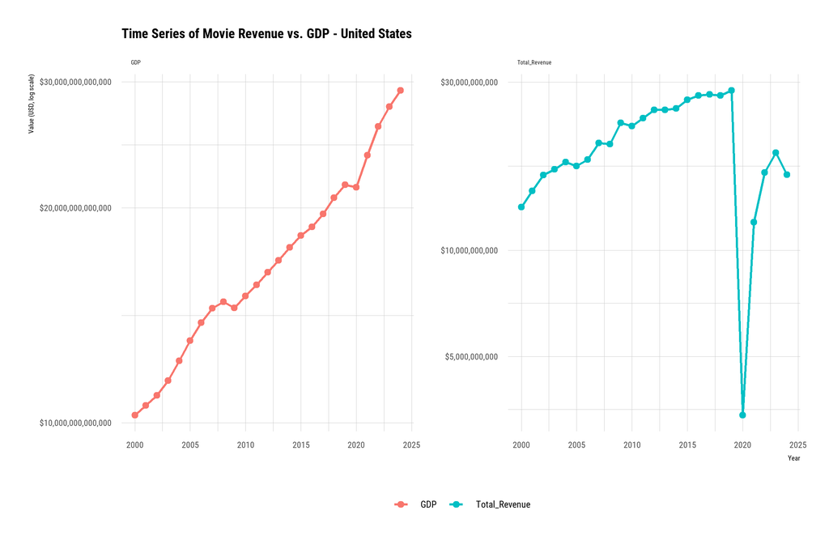

```r
# Source: OpenAI
# Model: GPT-5
focus_country <- "United States"

analysis_country %>%
  filter(Country_Name == focus_country) %>%
  group_by(Year) %>%
  summarise(
    Total_Revenue = sum(Total_Revenue, na.rm = TRUE),
    GDP = sum(GDP, na.rm = TRUE),
    .groups = "drop"
  ) %>%
  pivot_longer(cols = c(Total_Revenue, GDP), names_to = "Metric", values_to = "Value") %>%
  ggplot(aes(x = Year, y = Value, colour = Metric)) +
  geom_line(size = 1.1) +
  geom_point(size = 2) +
  scale_y_log10(labels = dollar_format()) +
  facet_wrap(~Metric, scales = "free_y") +
  labs(
    title = paste("Time Series of Movie Revenue vs. GDP -", focus_country),
    x = "Year",
    y = "Value (USD, log scale)",
    colour = NULL
  ) +
  theme(legend.position = "bottom")
```

### **Overall Insights**:

- The plot shows that while **GDP growth** remained steady, the **movie industry** experienced significant volatility, particularly in 2020 due to the COVID-19 pandemic. The recovery of the movie industry post-pandemic is visible, though it has yet to reach pre-pandemic revenue levels. The log scale helps to show the relationship between the two variables, providing clarity despite the large differences in value between GDP and movie revenue.

### 4.3.9 **Horizontal Bar Plot of Top 10 Countries by Total Movie Revenue**

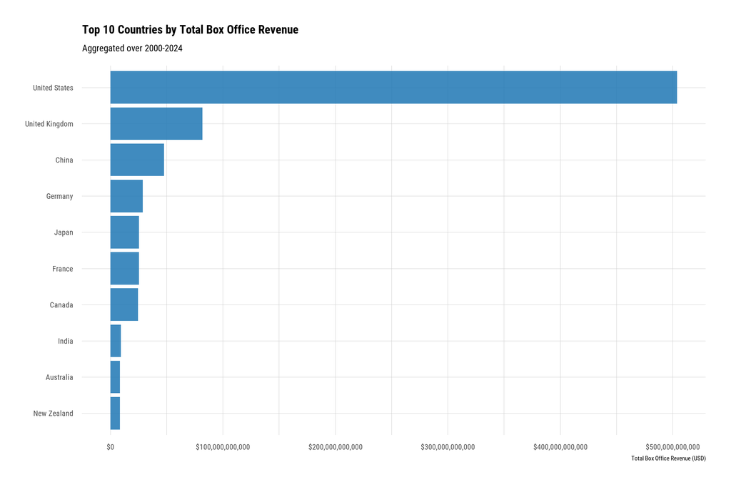

```r
# Source: OpenAI
# Model: GPT-5
n_top <- 10

analysis_country %>%
  group_by(Country_Name) %>%
  summarise(
    Total_Revenue = sum(Total_Revenue, na.rm = TRUE),
    .groups = "drop"
  ) %>%
  arrange(desc(Total_Revenue)) %>%
  slice_head(n = n_top) %>%
  ggplot(aes(x = reorder(Country_Name, Total_Revenue), y = Total_Revenue)) +
  geom_col(fill = "#1F77B4", alpha = 0.85) +
  coord_flip() +
  scale_y_continuous(labels = dollar_format()) +
  labs(
    title = paste("Top", n_top, "Countries by Total Box Office Revenue"),
    subtitle = "Aggregated over 2000-2024",
    x = NULL,
    y = "Total Box Office Revenue (USD)"
  )
```

#### **Explanation of the Visualization: Top 10 Countries by Total Box Office Revenue (2000–2024)**

1. **X-Axis (Total Box Office Revenue in USD)**:
   - The x-axis represents the **total box office revenue** for each country, aggregated over the period from **2000 to 2024**. The values are displayed in **USD**, and the scale helps to compare the revenue generated by each country’s film industry.
2. **Y-Axis (Countries)**:
   - The y-axis lists the **top 10 countries** based on total box office revenue. The countries are ranked from the highest to the lowest revenue-generating countries in the dataset.
3. **Bar Representation (Box Office Revenue)**:
   - Each bar represents the total **box office revenue** for a country over the 2000-2024 period. The bars are horizontal and color-coded in **blue**.
   - **United States** leads by a significant margin, with a much longer bar compared to the other countries. The **United Kingdom** follows with a considerably smaller revenue but still notable, followed by countries like **China**, **Germany**, and **Japan**.
   - The **length of each bar** shows the total revenue, with countries like the U.S. generating over **$500 billion** in movie revenue, while countries like **New Zealand** generate less.
4. **Key Observations**:
   - The **United States** is by far the largest contributor to global box office revenue, with the revenue significantly higher than the other countries.
   - **United Kingdom** and **China** follow as the next highest, but their revenues are considerably smaller compared to the U.S.
   - **Germany**, **Japan**, **France**, **Canada**, **India**, **Australia**, and **New Zealand** round out the top 10, with progressively smaller bars indicating lower total box office earnings.
5. **Purpose of the Visualization**:
   - This bar chart highlights the dominance of the U.S. in global box office revenue and allows for easy comparison of the contributions of the next top countries. It shows the economic impact of the film industry across different countries and helps to understand the scale of movie revenue generated globally.
6. **Context**:
   - The chart provides insights into the relative success of different countries’ film industries in terms of box office performance. It shows the disparity between the leading film markets, like the U.S., and other countries, which may have smaller but still significant contributions to global movie revenues.

**Overall Insights**: - The visualization clearly shows that the **United States** is the dominant player in the global movie market, generating far more revenue than any other country. However, countries like the **United Kingdom** and **China** also play significant roles in global box office earnings, with other countries contributing at smaller scales. This chart offers a snapshot of the economic influence of the film industry by country.

### 4.3.10 **Horizontal Bar Plot to Show Top 10 Countries by Average GDP**

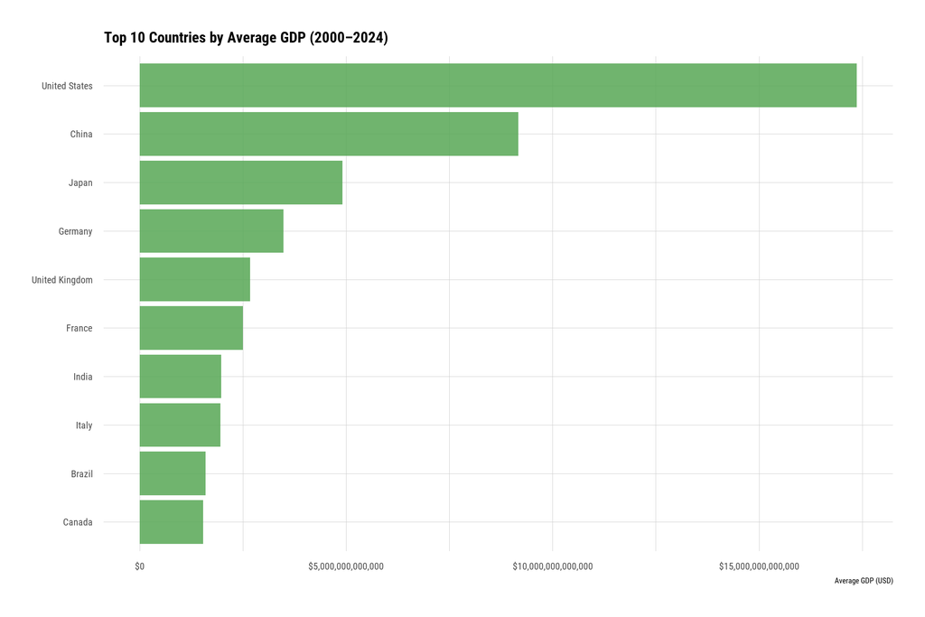

```r
# Source: OpenAI
# Model: GPT-5
n_top <- 10

analysis_country %>%
  group_by(Country_Name) %>%
  summarise(
    Avg_GDP = mean(GDP, na.rm = TRUE),
    .groups = "drop"
  ) %>%
  arrange(desc(Avg_GDP)) %>%
  slice_head(n = n_top) %>%
  ggplot(aes(x = reorder(Country_Name, Avg_GDP), y = Avg_GDP)) +
  geom_col(fill = "#57a755", alpha = 0.85) +
  coord_flip() +
  scale_y_continuous(labels = scales::dollar_format()) +
  labs(
    title = "Top 10 Countries by Average GDP (2000–2024)",
    x = NULL,
    y = "Average GDP (USD)"
  )
```

#### Explanation of the Visualization: Top 10 Countries by Average GDP (2000–2024)

**Overall Insights**: - The visualization clearly shows that the **United States** has the largest economy by far, followed by **China**, while other countries like **Japan**, **Germany**, and **India** have significantly smaller average GDPs. This chart underscores the dominance of the U.S. and China in the global economy, with other countries trailing behind in terms of average GDP.

# 5. **Feature Engineering and Selection**

## 5.1 **Data Preparation for Modeling and Feature Selection**

```r
# Source: OpenAI
# Model: GPT-5
analysis_model <- box_office_clean %>%
  mutate(
    Primary_Country = Production_Countries,
    Total_Revenue = `$Worldwide`
  ) %>%
  left_join(gdp_data_long %>% select(Country_Name, Year, GDP),
            by = c("Primary_Country" = "Country_Name", "Year")) %>%
  left_join(
    pop_data_clean %>% select(
      Name, Year, Population, `Male Population`, `Female Population`,
      `Annual Growth Rate`, `Life Expectancy at Birth, Both Sexes`
    ),
    by = c("Primary_Country" = "Name", "Year")
  ) %>%
  filter(GDP > 0, Population > 0) %>%
  mutate(
    Relative_Revenue = Total_Revenue / GDP,
    High_Revenue = factor(
      if_else(Relative_Revenue > median(Relative_Revenue, na.rm = TRUE),
              "High", "Low"),
      levels = c("Low", "High")
    ),
    GDP_per_Capita = GDP / Population,
    Male_Female_Ratio = `Male Population` / `Female Population`,
    Growth_Rate = `Annual Growth Rate`,
    Life_Expectancy = `Life Expectancy at Birth, Both Sexes`
  ) %>%
  select(
    Primary_Country,
    Total_Revenue,
    Rating,
    Vote_Count,
    GDP,
    Population,
    GDP_per_Capita,
    Growth_Rate,
    Life_Expectancy,
    Male_Female_Ratio,
    Relative_Revenue,
    High_Revenue
  ) %>%
  drop_na(High_Revenue)
```

### Explanation for Creating a Movie-Level Dataset

1. **Creating New Columns**:
   - **Primary_Country**: A new column is created that mirrors the `Production_Countries` column. This simplifies further analysis and ensures that country-level data can be easily merged.
   - **Total_Revenue**: A new column is created to store the worldwide box office revenue, represented by the `"$Worldwide"` column.
2. **Merging with GDP Data**:
   - The `left_join()` function is used to merge the `box_office_clean` dataset with the `gdp_data_long` dataset. The join is performed by matching `Primary_Country` with `Country_Name` and `Year`. This adds the GDP data for each country-year combination, allowing for economic context in the analysis.
3. **Merging with Population Data**:
   - Another `left_join()` is applied to merge the GDP-enhanced dataset with the `pop_data` dataset. The join is done by matching `Primary_Country` (from the box office and GDP data) with `Name` (from the population data) and the `Year`. The `select()` function ensures only relevant population columns — `Name`, `Year`, `Population`, `Male Population`, `Female Population`, `Annual Growth Rate`, and `Life Expectancy at Birth, Both Sexes` — are kept.
4. **Filtering Invalid Data**:
   - The `filter()` function is used to remove rows where **GDP** or **Population** is less than or equal to zero, ensuring only valid records are included in the analysis.
5. **Creating New Features**:
   - **Relative_Revenue**: A new feature is created by dividing the **Total Revenue** of each movie by the GDP of the country. This allows for the comparison of movie revenues in relation to a country’s economic size.
   - **High_Revenue**: A binary categorical variable is created using `if_else()`, where movies with a **relative revenue greater than the median** are classified as “High” revenue, and those below the median as “Low”. The `factor()` function ensures the variable has the appropriate levels for further analysis.
   - **GDP_per_Capita**: The GDP per capita is calculated by dividing GDP by the population. This provides a measure of the economic wealth available per person in each country.
   - **Male_Female_Ratio**: The ratio of male to female population is calculated by dividing the male population by the female population, providing demographic context.
   - **Growth_Rate**: The `Annual Growth Rate` of the population is retained as a feature.
   - **Life_Expectancy**: The life expectancy at birth for both sexes is retained as a feature, providing further demographic context.
6. **Selecting Relevant Columns**:
   - The `select()` function is used to choose the most relevant columns for further analysis, including country, revenue, GDP, population, GDP per capita, growth rate, life expectancy, and the revenue classification (High/Low).
7. **Removing Missing Data**:
   - The `drop_na()` function is used to remove rows with missing values in the **High_Revenue** column. This ensures that only complete cases are included in the final dataset for modeling.
8. **Result**:
   - The resulting `analysis_model` dataset contains all the necessary features, including the newly created ones, and is ready for further feature selection and modeling. It includes information on movie revenue, GDP, population, demographic factors, and the classification of movies as high or low revenue.

### Reasoning Behind the Process:

- **Why Merge the Data with GDP and Population?**
  - Merging GDP and population data allows the inclusion of important economic and demographic context for each country-year combination. This context helps to better understand how factors like GDP, population size, and demographic distribution (e.g., male-to-female ratio) may affect movie revenue.
- **Why Create `Relative_Revenue`?**
  - `Relative_Revenue` normalizes the movie revenue by country GDP, allowing for a fairer comparison of movie performance across countries of different economic sizes. This is essential for understanding how a movie performs relative to the economy in which it was produced.
- **Why Use `High_Revenue` as a Target Variable?**
  - Classifying movies as “High” or “Low” revenue based on relative revenue allows for easier classification and analysis. This categorization helps in feature selection and simplifies predictive modeling, making it easier to identify factors that influence high-revenue movies.
- **Why Filter for Valid Data?**
  - Filtering out invalid data (e.g., zero or negative GDP and population) ensures that the analysis is based on meaningful and valid observations, preventing skewed results due to missing or erroneous data.

## 5.2 **Feature Engineering: Removing Columns with Unique Values**

```r
# Source: OpenAI
# Model: GPT-5
analysis_model <- analysis_model %>% mutate(Row_ID = row_number())

unique_cols <- names(analysis_model)[
  sapply(analysis_model, function(col) dplyr::n_distinct(col) == nrow(analysis_model))
]
unique_cols <- setdiff(unique_cols, c("High_Revenue", "Relative_Revenue", "Row_ID"))
analysis_model <- analysis_model %>% select(-all_of(unique_cols))
```

### Explanation of Removing Columns with Unique Values

1. **Creating a Unique Row Identifier**:
   - The `mutate()` function is used to create a new column called **Row_ID**, which assigns a unique identifier to each row in the `analysis_model` dataset. This is achieved using the `row_number()` function, which generates a sequence of numbers from 1 to the total number of rows in the dataset. The `Row_ID` column is useful for referencing specific rows in the dataset during further analysis or modeling.
2. **Identifying Unique Columns**:
   - The `sapply()` function is used to check each column in the `analysis_model` dataset to determine if it contains only **unique values**. The function `dplyr::n_distinct(col)` counts the number of distinct values in a column, and `nrow(analysis_model)` returns the total number of rows in the dataset. If the number of distinct values is equal to the total number of rows, it means the column contains unique values for each row.
   - The result of `sapply()` is a logical vector, and **`unique_cols`** stores the names of the columns that have unique values.
3. **Excluding Specific Columns from Removal**:
   - The `setdiff()` function is used to remove the columns that should **not** be removed from `unique_cols`. The columns `High_Revenue`, `Relative_Revenue`, and `Row_ID` are excluded from removal because they are important for analysis (e.g., `High_Revenue` for classification, `Relative_Revenue` for comparison, and `Row_ID` for unique identification).
4. **Removing Unique Columns**:
   - The `select()` function is used to remove the columns identified in `unique_cols` from the `analysis_model` dataset. The **`all_of()`** function ensures that the column names in `unique_cols` are correctly referenced and passed to `select()` for removal.
   - The resulting dataset is now stripped of any columns that contained unique values, leaving only those that provide meaningful, non-redundant information for further analysis or modeling.

### Reasoning Behind the Process:

- **Why Add `Row_ID`?**
  - The `Row_ID` column is added to uniquely identify each row in the dataset. This is useful for tracking or referencing individual observations during analysis and ensuring that each row can be uniquely identified, especially when performing operations like filtering, sorting, or merging data.
- **Why Remove Columns with Unique Values?**
  - Columns with unique values do not provide useful information for analysis or modeling, as they do not have variability across the dataset. For instance, a column containing only unique identifiers (like `Row_ID`) does not contribute to predictive models or statistical analysis. Removing such columns helps reduce noise in the dataset and ensures that only meaningful features are included.
- **Why Keep `High_Revenue`, `Relative_Revenue`, and `Row_ID`?**
  - **`High_Revenue`** is an important categorical variable used to classify movies based on their relative performance.
  - **`Relative_Revenue`** provides context for how a movie performs relative to the country’s GDP, which is crucial for understanding movie success in economic terms.
  - **`Row_ID`** is a unique identifier for each observation and is necessary for referencing and tracking rows in the dataset.

## 5.3 **Creating a Violin Plot to Visualize Feature Distributions by Revenue Category**

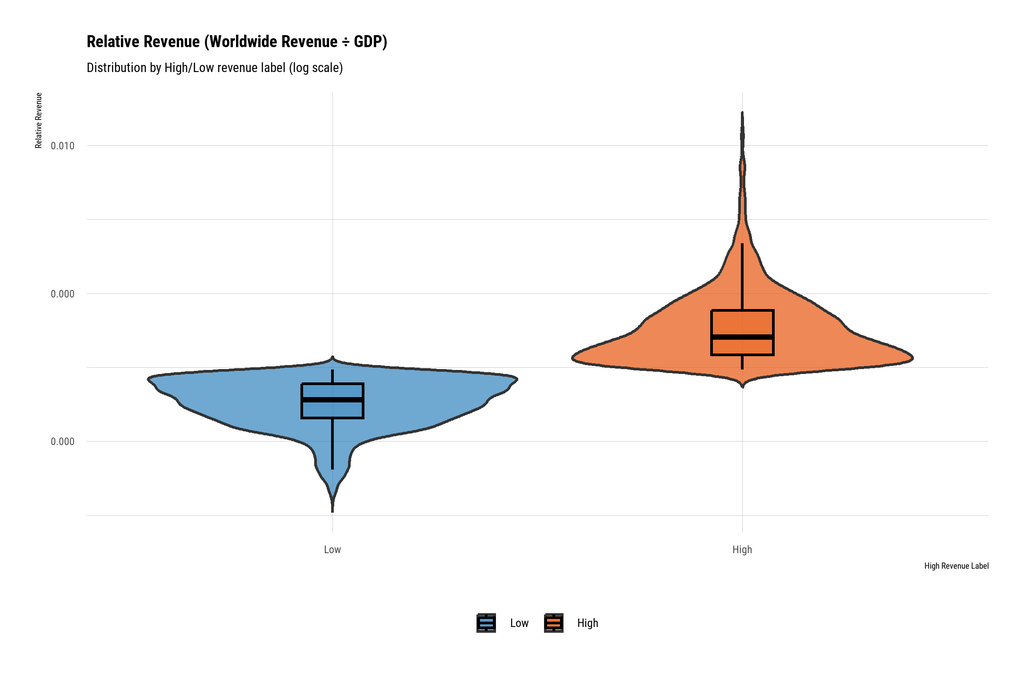

```r
analysis_model %>%
  filter(!is.na(Relative_Revenue)) %>%
  ggplot(aes(x = High_Revenue, y = Relative_Revenue, fill = High_Revenue)) +
  geom_violin(trim = FALSE, alpha = 0.7) +
  geom_boxplot(width = 0.15, outlier.shape = NA, alpha = 0.4, colour = "black") +
  scale_y_log10(labels = scales::number_format(accuracy = 0.001)) +
  scale_fill_manual(values = c("Low" = "#3182bd", "High" = "#e6550d")) +
  labs(
    title = "Relative Revenue (Worldwide Revenue \u00f7 GDP)",
    subtitle = "Distribution by High/Low revenue label (log scale)",
    x = "High Revenue Label",
    y = "Relative Revenue",
    fill = NULL
  )
```

### Explanation of the Visualization: Relative Revenue (Worldwide Revenue ÷ GDP) by High/Low Revenue Label

1. **X-Axis (High/Low Revenue Label)**:
   - The x-axis represents the **High/Low Revenue** classification, with two categories:
     - **Low**: Movies that fall below the median relative revenue.
     - **High**: Movies that exceed the median relative revenue.
   - These classifications are based on the **relative revenue**, which is calculated as **Worldwide Revenue ÷ GDP**.
2. **Y-Axis (Relative Revenue)**:
   - The y-axis represents the **relative revenue** of movies, which is the ratio of **total worldwide revenue** to the **GDP** of the country. This measure normalizes revenue by considering the economic size of the country.
3. **Violin Plot Representation**:
   - The plot is a **violin plot** that shows the distribution of relative revenue for **low** and **high** revenue movies.
     - The **blue area** represents the distribution of relative revenue for **low revenue movies**, and the **orange area** represents the distribution of relative revenue for **high revenue movies**.
     - The width of the “violin” at each value of relative revenue indicates the density of data points at that value.
     - The **box inside each violin** shows the **interquartile range (IQR)**, with a line representing the **median** relative revenue. This highlights where most of the data lies and the spread of relative revenue within each category.
4. **Key Observations**:
   - **High revenue movies (orange)** tend to have a **wider distribution** with a longer tail, indicating that there is a greater spread in the relative revenue for high-revenue movies. This suggests that high-revenue movies come from a diverse set of countries, with varying levels of GDP.
   - **Low revenue movies (blue)** show a **narrower distribution**, indicating that most low-revenue movies are clustered around lower relative revenue values, with less variation compared to high-revenue movies.
   - The **median relative revenue** for **high revenue movies** is significantly higher than for **low revenue movies**, reflecting that high-revenue movies tend to perform much better relative to the economic size of the country in which they are produced.
5. **Purpose of the Log-Scale**:
   - The **log scale** on the y-axis helps to compress large differences in relative revenue, making it easier to observe patterns in both low and high relative revenue movies, especially when there are extreme values that would otherwise skew the visualization.
6. **Context**:
   - This violin plot allows for a deeper understanding of how **relative revenue** varies between movies with low and high box office earnings, taking into account the economic context of the country. It highlights the disparity between movies that perform exceptionally well compared to their country’s GDP and those that perform poorly, giving insights into what drives successful movie performance globally.

**Overall Insights**: - The visualization shows that **high-revenue movies** tend to have **higher relative revenue** compared to **low-revenue movies**, with a broader spread of data. This suggests that while high-revenue movies outperform relative to the GDP of their respective countries, low-revenue movies show less variation and are typically underperforming in comparison to their country’s economy. The log scale helps to visualize these patterns more effectively, making the differences between the two groups clearer.

## 5.4 **Creating a Baseline Single Variable Model and Binary Target Classification**

### Define Helper functions

`loglikelihood`

```r
# Source: OpenAI
# Model: GPT-5
logLikelihood <- function(ypred, ytrue) {
  eps <- 1e-10
  ypred <- pmin(pmax(ypred, eps), 1 - eps)
  sum(ifelse(ytrue, log(ypred), log(1 - ypred)), na.rm = TRUE)
}
```

#### Explanation of the `logLikelihood` Function

The `logLikelihood` function is used to compute the **log-likelihood** for binary classification problems, such as predicting the **High_Revenue** label (either “High” or “Low”) for movies. Log-likelihood is a measure of how well the predicted probabilities (from a model) match the observed values (true labels).

1. **Input Parameters**:
   - **`ypred`**: The predicted probabilities, which represent the likelihood that each observation belongs to the “High” class.
   - **`ytrue`**: The actual observed values, which are the true labels (either 1 for “High” revenue or 0 for “Low” revenue).
2. **Clipping Predicted Probabilities (`ypred`)**:
   - `eps <- 1e-10`: This sets a small epsilon value (`1e-10`) to prevent numerical issues with very small or very large predicted probabilities.
   - `ypred <- pmin(pmax(ypred, eps), 1 - eps)`: This step clips the predicted probabilities to ensure they stay within a reasonable range. Probabilities are clipped between `eps` (0.0000000001) and `1 - eps` (0.9999999999) to avoid taking the logarithm of zero or one, which would result in undefined or infinite values.
3. **Computing the Log-Likelihood**:
   - `sum(ifelse(ytrue, log(ypred), log(1 - ypred)), na.rm = TRUE)`: This computes the log-likelihood by:
     - **For “High” revenue movies (where `ytrue = 1`)**: It calculates `log(ypred)`, the logarithm of the predicted probability for the “High” class.
     - **For “Low” revenue movies (where `ytrue = 0`)**: It calculates `log(1 - ypred)`, the logarithm of the predicted probability for the “Low” class (i.e., the complement of the “High” class).
     - The `sum()` function aggregates these log-likelihood values across all observations, and `na.rm = TRUE` ensures that any missing values are ignored during the calculation.
4. **Purpose**:
   - **Log-likelihood** is a key metric in many machine learning algorithms, including logistic regression. It measures how well the predicted probabilities align with the actual outcomes. A **higher log-likelihood** indicates a better model, as it means the predicted probabilities are closer to the actual labels.

`add_single_prob_column`

```r
# Source: OpenAI
# Model: GPT-5
add_single_prob_column <- function(data, feature, outcome = "High_Revenue") {
  cols <- c(outcome, feature)
  cols <- cols[cols %in% colnames(data)]
  if (length(cols) < 2) return(data)
  train_idx <- complete.cases(data[, cols])
  if (!any(train_idx)) return(data)
  formula <- as.formula(paste(outcome, "~", feature))
  fit <- glm(formula, data = data[train_idx, cols, drop = FALSE], family = binomial())
  preds <- predict(fit, newdata = data, type = "response")
  data[[paste0("pred_", feature)]] <- preds
  data
}
```

#### Explanation of the `add_single_prob_column` Function

The `add_single_prob_column` function adds a **predicted probability** column for a single feature to the dataset based on a **logistic regression model**. The predicted probability is calculated using the specified feature and the target variable (default is `"High_Revenue"`).

#### Input Parameters:

- **`data`**: The dataset containing the feature and outcome (target variable) for which the probability will be predicted.
- **`feature`**: The feature (predictor) to be used in the logistic regression model. This feature will be used to predict the target variable (`High_Revenue` by default).
- **`outcome`**: The target variable, which defaults to `"High_Revenue"`. This variable represents the binary classification (either “High” or “Low” revenue).

#### Function Steps:

1. **Check if Feature and Outcome Columns Exist**:
   - The `cols` vector contains the `outcome` and `feature` column names. It then checks if both columns exist in the dataset (`data`). If either of the columns is missing, the function returns the original dataset without changes.
2. **Handle Missing Data**:
   - `train_idx <- complete.cases(data[, cols])` identifies rows that have complete data for both the feature and outcome columns. The `complete.cases()` function returns a logical vector indicating which rows have non-missing values for the selected columns.
   - If no rows have complete data (`train_idx` is empty), the function returns the original dataset without adding any predictions.
3. **Fit Logistic Regression Model**:
   - The formula for logistic regression is dynamically created using the specified `outcome` and `feature`. The `glm()` function is used to fit a logistic regression model on the subset of data with complete cases for the selected columns (`data[train_idx, cols, drop = FALSE]`).
   - The model is fitted using a **binomial** family, which is appropriate for binary classification problems like this one.
4. **Generate Predictions**:
   - The `predict()` function is used to generate predicted probabilities (`preds`) for the entire dataset, including rows with missing values. The `type = "response"` argument ensures that the predictions are probabilities (ranging from 0 to 1).
5. **Add Predictions to Dataset**:
   - The predicted probabilities are added to the dataset as a new column. The column name is dynamically created as `"pred_"` followed by the feature name. This new column contains the predicted probability of a movie being classified as “High” revenue based on the selected feature.
6. **Return Modified Dataset**:
   - The modified dataset, which now includes the predicted probability for the selected feature, is returned.

#### Reasoning Behind the Process:

- **Why Predict Probability Instead of a Class Label?**
  - Predicting probabilities rather than hard class labels allows for more flexibility in decision-making. The probability can be used to make more informed decisions, such as choosing a threshold for classification or calculating other performance metrics like AUC (Area Under the Curve).
- **Why Handle Missing Data?**
  - The function ensures that only rows with complete data for the selected feature and outcome are used to fit the model. Handling missing data in this way ensures that the model is trained only on valid data, avoiding issues caused by incomplete cases.

`add_prob_columns`

```r
add_prob_columns <- function(data, features, outcome = "High_Revenue") {
  for (feature in unique(features)) {
    data <- add_single_prob_column(data, feature, outcome)
  }
  data
}
```

#### Explanation of the `add_prob_columns` Function

The `add_prob_columns` function is designed to iterate over multiple features and add the predicted probabilities for each feature to the dataset. It utilizes the previously defined `add_single_prob_column` function to compute and append the predicted probabilities for each feature in the `features` list.

#### Input Parameters:

- **`data`**: The dataset to which the predicted probability columns will be added.
- **`features`**: A vector of feature names (predictors) for which the predicted probabilities will be calculated. Each feature will be used individually to predict the target variable (`High_Revenue`).
- **`outcome`**: The target variable, which defaults to `"High_Revenue"`. This variable represents the binary classification of a movie’s revenue as either “High” or “Low”.

#### Function Steps:

1. **Iterating Over Features**:
   - The `for` loop iterates over each **unique feature** in the `features` list. This ensures that the function works on each feature separately, calculating its predicted probability with respect to the target variable (`High_Revenue`).
2. **Calling `add_single_prob_column`**:
   - For each feature in the `features` list, the function calls the `add_single_prob_column()` function, which computes the predicted probabilities based on the logistic regression model for that feature.
   - These predicted probabilities are added as a new column to the `data` dataset, with the column name being `"pred_"` followed by the feature name.
3. **Returning the Modified Dataset**:
   - After iterating through all features and adding the predicted probabilities, the modified dataset is returned, now containing additional columns for the predicted probabilities of each feature.

#### Reasoning Behind the Process:

- **Why Iterate Over Multiple Features?**
  - By iterating over multiple features, this function allows you to add the predicted probabilities for all the selected predictors in one go, rather than having to apply the `add_single_prob_column()` function individually for each feature.
  - This is efficient, especially when working with multiple predictors that need to be assessed for their predictive power.
- **Why Use `add_single_prob_column`?**
  - The function `add_single_prob_column` is used for calculating and adding the predicted probabilities for each individual feature. This modular approach allows for easy reuse and extension.

### 5.4.1 **Model Features Defination and Calculation of Null Probability and Deviance for Baseline Model**

- The **null model** is a baseline model that simply predicts the majority class (in this case, “High” revenue) for all observations. The probability is calculated as the proportion of “High” revenue movies relative to the total number of movies.
- **Deviance** is a measure of model fit, calculated as `-2 * logLikelihood`. The `logLikelihood` measures how well the model’s predictions match the actual data.
- The **null deviance** is computed by comparing the predicted values of the null model (which predicts `null_prob_single` for all rows) with the actual observed values of `High_Revenue`. This provides a baseline for evaluating how much improvement can be made with the inclusion of additional features.

```r
# Source: OpenAI
# Model: GPT-5
model_features <- c(
  "Rating",
  "Vote_Count",
  "GDP",
  "Population",
  "GDP_per_Capita",
  "Growth_Rate",
  "Life_Expectancy",
  "Male_Female_Ratio"
)

model_frame_all <- analysis_model %>%
  select(Row_ID, High_Revenue, all_of(model_features))

model_frame_complete <- model_frame_all %>% drop_na()

null_prob_single <- mean(model_frame_complete$High_Revenue == "High")
null_deviance_single <- -2 * logLikelihood(
  rep(null_prob_single, nrow(model_frame_complete)),
  model_frame_complete$High_Revenue == "High"
)

single_var_stats <- data.frame(
  Variable = character(),
  AUC = numeric(),
  Deviance = numeric(),
  Deviance_Reduction = numeric(),
  stringsAsFactors = FALSE
)
```

#### Explanation of the Code: Model Features and Calculation of Null Deviance for Baseline Model

1. **Defining Model Features**:
   - The `model_features` vector lists the columns to be used as features in the model. These features include:
     - **Rating**: The average rating of the movie.
     - **Vote_Count**: The number of votes the movie has received.
     - **GDP**: The GDP of the country in which the movie was produced.
     - **Population**: The population of the country.
     - **GDP_per_Capita**: The GDP per capita of the country.
     - **Growth_Rate**: The annual growth rate of the country’s population.
     - **Life_Expectancy**: The life expectancy at birth for both sexes in the country.
     - **Male_Female_Ratio**: The ratio of the male to female population in the country.
   - These variables are selected to provide a comprehensive set of predictors based on economic and demographic factors that could influence movie revenue.
2. **Creating the Model Data Frame**:
   - `model_frame_all` is created by selecting the **Row_ID**, **High_Revenue**, and the features defined in `model_features` from the `analysis_model` dataset.
   - This results in a data frame that contains the variables relevant for building the model, including the target variable **High_Revenue** (which is the classification of movies as “High” or “Low” revenue) and the selected predictors.
3. **Handling Missing Data**:
   - `model_frame_complete` is created by applying `drop_na()` to the `model_frame_all` dataset. This function removes any rows with missing values, ensuring that only complete data is used for modeling. This is crucial because missing values could lead to incorrect model training or biased results.
4. **Calculating the Null Model Probability**:
   - The `null_prob_single` is the **probability** of a “High” revenue movie in the dataset, calculated as the **proportion of “High” revenue movies** in `model_frame_complete`. This is used as the prediction for all rows in the null model.
5. **Calculating Null Deviance**:
   - The **null deviance** is computed by comparing the predicted values of the null model (which predicts `null_prob_single` for all rows) with the actual observed values of `High_Revenue`. This provides a baseline for evaluating how much improvement can be made with the inclusion of additional features.

#### Reasoning Behind the Process:

- **Why Use `null_prob_single`?**
  - The null model serves as a reference to evaluate the performance of more complex models. By using the most frequent outcome (“High” revenue) as the prediction, it provides a baseline against which the effectiveness of the features in predicting movie revenue can be assessed.
- **Why Calculate the Null Deviance?**
  - The null deviance represents the performance of the simplest model (the null model). It is useful for comparing how much better a model that includes features performs compared to the null model. A reduction in deviance indicates that the features contribute to explaining the outcome better than just predicting the majority class.
- **Why Drop Missing Data?**
  - Dropping rows with missing data ensures that the model is trained on complete cases, preventing any biases or issues that might arise from missing values.

## 5.5 **Evaluating Single Variable Model**

```r
# Source: OpenAI
# Model: GPT-5
single_var_stats <- data.frame(
  Variable = character(),
  AUC = numeric(),
  Deviance = numeric(),
  Deviance_Reduction = numeric(),
  stringsAsFactors = FALSE
)

for (var in model_features) {
  formula <- as.formula(paste("High_Revenue ~", var))
  single_model <- glm(formula, data = model_frame_complete, family = "binomial")
  preds_full <- predict(single_model, type = "response")

  auc_value_full <- auc(roc(model_frame_complete$High_Revenue, preds_full))
  loglik_full <- logLikelihood(preds_full, model_frame_complete$High_Revenue == "High")
  deviance_full <- -2 * loglik_full
  deviance_drop <- null_deviance_single - deviance_full

  single_var_stats <- rbind(
    single_var_stats,
    data.frame(
      Variable = var,
      AUC = round(auc_value_full, 4),
      Deviance = round(deviance_full, 4),
      Deviance_Reduction = round(deviance_drop, 4),
      stringsAsFactors = FALSE
    )
  )

}
```

#### Explanation of the Code: Evaluating Single Variable Models

1. **Creating an Empty Data Frame for Model Statistics**:
   - `single_var_stats` is initialized as an empty data frame to store the statistics for each model, including:
     - **Variable**: The name of the feature being modeled.
     - **AUC (Area Under the Curve)**: A measure of the model’s ability to discriminate between “High” and “Low” revenue movies.
     - **Deviance**: A measure of the model’s fit, calculated as `-2 * log-likelihood`.
     - **Deviance Reduction**: The reduction in deviance from the null model to the feature-based model, indicating how much better the model with the feature performs compared to the baseline.
2. **Looping Over Each Feature**:
   - The `for` loop iterates over each variable in `model_features` and fits a **logistic regression model** for each feature. The formula is created dynamically using `as.formula(paste("High_Revenue ~", var))`, where `var` is the current feature.
3. **Fitting a Logistic Regression Model**:
   - `glm()` is used to fit a logistic regression model with the target variable (`High_Revenue`) and the current feature (`var`). The `family = "binomial"` argument specifies that this is a binary classification problem, as we are predicting whether a movie has “High” or “Low” revenue.
4. **Making Predictions**:
   - `predict(single_model, type = "response")` generates predicted probabilities (`preds_full`) for the target variable using the fitted model. These probabilities represent the likelihood that each movie is classified as “High” revenue.
5. **Calculating AUC (Area Under the Curve)**:
   - The `roc()` function from the **pROC** package is used to compute the **Receiver Operating Characteristic (ROC) curve** based on the true labels (`model_frame_complete$High_Revenue`) and the predicted probabilities (`preds_full`).
   - `auc()` computes the **AUC** score, which measures the model’s ability to distinguish between “High” and “Low” revenue movies. A higher AUC indicates better performance.
6. **Calculating Deviance**:
   - `loglik_full` calculates the **log-likelihood** of the model’s predictions (`preds_full`) against the true outcomes (`model_frame_complete$High_Revenue == "High"`).
   - **Deviance** is then calculated as `-2 * loglik_full`, which measures how well the model fits the data.
   - The **deviance reduction** is computed as the difference between the **null deviance** (baseline model) and the **current model deviance**. A larger reduction indicates that the model with the feature is much better than the baseline model.
7. **Storing the Results**:
   - The statistics for each model (AUC, Deviance, Deviance Reduction) are stored in `single_var_stats` using `rbind()`, which adds a new row to the data frame for each feature. The results are rounded to 4 decimal places for clarity.
8. **Sorting by Deviance Reduction**:
   - After the loop finishes, `single_var_stats` is sorted in descending order of **Deviance Reduction** using `arrange(desc(Deviance_Reduction))`. This allows us to identify which features have the greatest impact on reducing deviance compared to the null model.

#### Reasoning Behind the Process:

- **Why Use AUC for Evaluation?**
  - **AUC** is a widely used metric for evaluating the performance of classification models, especially when dealing with imbalanced datasets. It tells us how well the model distinguishes between the two classes (“High” vs “Low” revenue movies). A higher AUC indicates better predictive performance.
- **Why Calculate Deviance and Deviance Reduction?**
  - **Deviance** measures how well the model fits the data. By comparing the **deviance of the feature-based model** with the **deviance of the null model**, we can evaluate how much improvement is gained by including the feature in the model. A greater **deviance reduction** indicates that the feature contributes meaningfully to the model.
- **Why Use Logistic Regression?**
  - Logistic regression is appropriate because we are predicting a binary outcome (whether a movie is “High” or “Low” revenue). It is a simple, interpretable model that provides probabilities for class membership.

### 5.5.1 **Observing Single-Variable Model Statistics**

1. **Sorting the Model Statistics**:
   - The `single_var_stats` data frame is sorted by the **Deviance Reduction** in descending order using `arrange(desc(Deviance_Reduction))`. This will rank the variables based on how much they reduce the deviance from the null model, allowing you to see which features have the greatest impact on improving the model’s fit.

```r
single_var_stats <- single_var_stats %>% arrange(desc(Deviance_Reduction))
print(single_var_stats)
```

```
##            Variable    AUC Deviance Deviance_Reduction
## 1        Vote_Count 0.8085 3783.251           833.6892
## 2               GDP 0.8133 4052.029           564.9117
## 3       Growth_Rate 0.7232 4166.420           450.5203
## 4        Population 0.7890 4395.732           221.2084
## 5   Life_Expectancy 0.5324 4602.195            14.7451
## 6            Rating 0.5190 4602.490            14.4506
## 7    GDP_per_Capita 0.5332 4613.896             3.0447
## 8 Male_Female_Ratio 0.5362 4614.279             2.6619
```

#### Next Steps:

- **Vote_Count**, **GDP**, and **Growth_Rate** are strong candidates for inclusion in a final model based on their high performance in both **AUC** and **Deviance Reduction**.
- Features like **Life_Expectancy**, **Rating**, and **Male_Female_Ratio** may be considered for exclusion or less emphasis, as they show limited improvement in model performance.

### 5.5.2 **Get Predictive Probabilities per Column**

The `add_prob_columns` function is applied to the analysis_model dataset to compute and add predicted probability columns based on the features defined in model_features. The target variable is “High_Revenue”, which is the binary outcome variable indicating whether a movie has high or low revenue.

```r
analysis_model <- add_prob_columns(
  analysis_model,
  model_features,
  outcome = "High_Revenue"
)
```

#### List and Print the First Few Rows of each `pred_*` column

```r
# Source: OpenAI
# Model: GPT-5
pred_cols <- grep("^pred_", names(analysis_model), value = TRUE)
analysis_model %>%
  select(High_Revenue, all_of(pred_cols)) %>%
  head() %>%
  print()
```

```
## # A tibble: 6 × 9
##   High_Revenue pred_Rating pred_Vote_Count pred_GDP pred_Population
##   <fct>              <dbl>           <dbl>    <dbl>           <dbl>
## 1 High               0.469           0.788    0.476           0.498
## 2 High               0.620           0.993    0.723           0.569
## 3 High               0.620           0.993    0.476           0.498
## 4 High               0.581           0.936    0.476           0.498
## 5 High               0.493           0.620    0.723           0.569
## 6 High               0.493           0.620    0.476           0.498
## # ℹ 4 more variables: pred_GDP_per_Capita <dbl>, pred_Growth_Rate <dbl>,
## #   pred_Life_Expectancy <dbl>, pred_Male_Female_Ratio <dbl>
```

#### Explanation of the Table: Predicted Probabilities for “High_Revenue” Classification

This table displays the predicted probabilities for movies being classified as **“High”** revenue based on various features in the dataset. The rows represent individual movies, and the columns represent both the predicted probabilities and the actual classification of each movie.

#### Example Insights:

In summary, this table helps to understand how each feature contributes to the prediction of a movie’s revenue status, and where there may be gaps in the data that need to be addressed.

## 5.6 **Null Model Exploration**

The **null model** serves as a baseline for model performance. It is important to compare our model’s accuracy against this baseline to understand whether the model is improving upon simply predicting the majority class.

### 5.6.1 Removing the Row_ID column from both datasets

```r
model_frame <- model_frame_complete %>% select(-Row_ID)
analysis_model <- analysis_model %>% select(-Row_ID)
```

#### Explanation of the Code: Removing the Row_ID Column from Datasets

1. **Removing the `Row_ID` Column from `model_frame`**:
   - The code `model_frame <- model_frame_complete %>% select(-Row_ID)` removes the **`Row_ID`** column from the `model_frame_complete` dataset.
   - **Reason**: The `Row_ID` column is an unique identifier for each row, which is useful for referencing individual observations during analysis but is not necessary for model fitting or statistical calculations.
   - By using `select(-Row_ID)`, the `Row_ID` column is excluded from the dataset, keeping only the relevant features for the modeling process.
2. **Removing the `Row_ID` Column from `analysis_model`**:
   - Similarly, `analysis_model <- analysis_model %>% select(-Row_ID)` removes the **`Row_ID`** column from the `analysis_model` dataset.
   - **Reason**: The `Row_ID` column is not required in the final model and might not be needed for further analyses. It is a non-predictive column that does not contribute to the relationships between the features and the target variable (e.g., **High_Revenue**).
   - Removing this column ensures that the dataset contains only the necessary features and target variables for model training or evaluation.

#### Reasoning Behind Removing `Row_ID`:

- **Purpose of `Row_ID`**:
  - The `Row_ID` is typically used as a unique identifier for each observation in the dataset. While it can be useful for tracking or referencing specific rows during analysis, it does not carry any meaningful information related to the model’s target or predictors.
- **Why Remove It for Modeling?**:
  - Including **`Row_ID`** in the modeling process would not add any predictive value, as it is simply a unique identifier for the rows and does not represent any feature that could help predict the outcome (e.g., **High_Revenue**).
  - Removing it ensures that the dataset used for modeling is clean and contains only relevant variables, which helps improve model efficiency and clarity.

### 5.6.2 Observing the Class Distribution of High_Revenue

```r
class_counts <- table(model_frame$High_Revenue)
print(class_counts)
```

```
##
##  Low High
## 1222 2383
```

#### Explanation of the Class Distribution:

Based on the output provided, we can see the frequency of each class in the **`High_Revenue`** variable:

- **Low Revenue**: 1,222 movies are classified as **Low** revenue.
- **High Revenue**: 2,383 movies are classified as **High** revenue.

#### Key Insights:

1. **Imbalanced Dataset**:
   - The dataset has a **higher number of “High” revenue movies (2,383)** compared to “Low” revenue movies (1,222). Although the imbalance is not extreme, the model might still favor the majority class (“High” revenue) due to this discrepancy.
2. **Impact on Model Performance**:
   - If the dataset were significantly imbalanced (e.g., much more “High” than “Low”), it could lead to **bias** in model predictions, where the model over-predicts the majority class. This can affect model evaluation metrics such as accuracy.
   - To mitigate this issue, techniques such as **resampling** (over-sampling the minority class or under-sampling the majority class), or using **class weights** in the model, could be considered.

### 5.6.3 Getting the Majority Class

1. **Identifying the Majority Class**:
   - `majority_class <- names(which.max(class_counts))`:
     - The `class_counts` table stores the counts of each class (“High” and “Low” revenue).
     - `which.max(class_counts)` identifies the index of the class with the highest count, which is the majority class.
     - `names()` is used to extract the name of the majority class (either `"Low"` or `"High"`) from the `class_counts` table.
     - This determines which class is more frequent in the dataset.

```r
majority_class <- names(which.max(class_counts))
null_accuracy <- mean(model_frame$High_Revenue == majority_class)
```

#### Printing the Majority Class

```r
cat(paste("Majority class:", majority_class, "\n"))
```

```
## Majority class: High
```

#### Explanation of the Output: Majority Class and Null Model Accuracy

1. **Majority Class**:
   - The output indicates that the **“High”** revenue class is the majority class in the dataset. This means that there are more movies classified as **“High” revenue** than **“Low” revenue**, as indicated by the class distribution.

#### Getting the Null Model Accuracy (Before Class Balancing)

```r
cat(paste0(
  "Null model accuracy (before balancing): ",
  round(null_accuracy, 4),
  " – matches the observed class imbalance.\n"))
```

```
## Null model accuracy (before balancing): 0.661 – matches the observed class imbalance.
```

## 5.7 Identify Numerical and Categorical Variables

```r
# Source: OpenAI
# Model: GPT-5
categorical_vars <- names(model_frame)[sapply(model_frame, is.factor)]
numerical_vars <- names(model_frame)[sapply(model_frame, is.numeric)]
```

### Explanation of the Code: Identifying Categorical and Numerical Variables

1. **Identifying Categorical Variables**:
   - `categorical_vars <- names(model_frame)[sapply(model_frame, is.factor)]`:
     - This line of code identifies **categorical variables** in the `model_frame` dataset.
     - The `sapply(model_frame, is.factor)` function checks each column of the dataset to determine if it is a **factor** (i.e., a categorical variable).
     - The `names(model_frame)` function retrieves the column names of the dataset, and `sapply()` returns a logical vector indicating whether each column is a factor or not. The result is then filtered to select only the categorical variables.
2. **Identifying Numerical Variables**:
   - `numerical_vars <- names(model_frame)[sapply(model_frame, is.numeric)]`:
     - This line of code identifies **numerical variables** in the `model_frame` dataset.
     - The `sapply(model_frame, is.numeric)` function checks each column to see if it is numeric (i.e., contains continuous or integer values).
     - Similar to the categorical variables, `names(model_frame)` retrieves the column names, and `sapply()` checks if each column is numeric. The result is then filtered to select only the numerical variables.

### Purpose of the Code:

- The purpose of this code is to **categorize** the variables in the `model_frame` dataset into **categorical** and **numerical** types. This distinction is important for analysis, as categorical variables are typically analyzed using techniques like chi-square tests or logistic regression with factors, while numerical variables are often used in linear regression or as continuous predictors in models.
- Understanding the types of variables helps in the subsequent analysis, such as **AUC (Area Under the Curve)** analysis for individual variables, where different approaches might be applied to categorical and numerical variables.

#### Printing the Identified Variables (Numerical and Categorical)

```r
cat("Categorical variables:", paste(categorical_vars, collapse = ", "), "\n")
```

```
## Categorical variables: High_Revenue
```

```r
cat("Numerical variables:", paste(numerical_vars, collapse = ", "), "\n")
```

```
## Numerical variables: Rating, Vote_Count, GDP, Population, GDP_per_Capita, Growth_Rate, Life_Expectancy, Male_Female_Ratio
```

#### Explanation of the Output: Categorical and Numerical Variables in the Dataset

1. **Categorical Variables**:
   - **High_Revenue**: This is the target variable that indicates whether a movie is classified as “High” or “Low” revenue. It is a **categorical variable**, where the values are either **“High”** or **“Low”**.
2. **Numerical Variables**:
   - The following variables are **numerical variables**, which typically represent continuous data and can be used as predictors in modeling:
     - **Rating**: The average rating of the movie.
     - **Vote_Count**: The number of votes the movie has received.
     - **GDP**: The GDP of the country in which the movie was produced.
     - **Population**: The population of the country.
     - **GDP_per_Capita**: The GDP per capita of the country.
     - **Growth_Rate**: The annual growth rate of the country’s population.
     - **Life_Expectancy**: The life expectancy at birth for both sexes in the country.
     - **Male_Female_Ratio**: The ratio of the male to female population in the country.

#### Key Insights:

- **High_Revenue** is the only categorical variable, and it represents the target variable used for classification (whether a movie’s revenue is “High” or “Low”).
- All other variables are numerical, meaning they contain continuous data that will be used to predict the **High_Revenue** outcome.

## 5.8 Determining Coorelation of Model Predictors

### 5.8.1 Visualize Coorelation Using a Coorelation Matrix

#### Explanation of the Code: Correlation Heatmap for Model Predictors

This code generates a **correlation heatmap** for the numerical predictors selected for the model. It uses **ggplot2** for visualization and **dplyr** for data manipulation to explore the relationships between predictor variables.

#### 1. **Selecting the Predictor Variables**:

- `predictor_vars <- intersect(model_features, numerical_vars)`:
  - This line identifies the **predictor variables** by finding the intersection between the list of **model features** (`model_features`) and **numerical variables** (`numerical_vars`).
  - It ensures that only numerical predictors from the model are selected for the correlation analysis.

#### 2. **Preparing the Data for Correlation Analysis**:

- `if (length(predictor_vars) > 1) {`:
  - The conditional check ensures that there are at least two predictor variables before proceeding with the correlation analysis.
- `predictor_numeric <- model_frame %>% select(all_of(predictor_vars)) %>% mutate(across(everything(), as.numeric)) %>% drop_na()`:
  - **Data Selection**: `select(all_of(predictor_vars))` selects the relevant predictor variables from the dataset (`model_frame`).
  - **Conversion to Numeric**: `mutate(across(everything(), as.numeric))` ensures that all selected predictor variables are converted to numeric types (if not already).
  - **Handling Missing Values**: `drop_na()` removes any rows with missing values in the selected predictor variables, ensuring a clean dataset for correlation analysis.

#### 3. **Calculating the Correlation**:

- `predictor_corr <- cor(predictor_numeric, use = "pairwise.complete.obs")`:
  - This line calculates the **correlation matrix** between the numeric predictors using **pairwise complete observations**, meaning that correlations are computed by ignoring missing values pairwise for each predictor.
- `predictor_corr_df <- as.data.frame(as.table(predictor_corr))`:
  - Converts the correlation matrix into a **long format** data frame, which is easier to plot using `ggplot2`.

#### 4. **Visualizing the Correlation Heatmap**:

- `ggplot(predictor_corr_df, aes(x = Var1, y = Var2, fill = Freq)) +`:
  - This line initializes the **ggplot** to create a heatmap of the correlation matrix.
  - `aes(x = Var1, y = Var2, fill = Freq)` maps the predictor variable pairs (`Var1` and `Var2`) on the x and y axes, and the correlation values (`Freq`) are used to determine the color fill.
- `geom_tile(colour = "white") +`:
  - This adds the colored tiles to the heatmap, with a white border between each tile.
- `scale_fill_gradient2(low = "#0571b0", mid = "white", high = "#ca0020", midpoint = 0, limits = c(-1, 1)) +`:
  - This defines the color gradient for the heatmap:
    - **Low values** (negative correlations) are colored in **blue** (`#0571b0`).
    - **High values** (positive correlations) are colored in **red** (`#ca0020`).
    - The midpoint of **0** represents **no correlation**, which is displayed in **white**.
- `labs(title = "Correlation Heatmap – Model Predictors", x = NULL, y = NULL, fill = "Correlation") +`:
  - This adds the title, and removes axis labels (x and y) for a cleaner plot. The **fill legend** is labeled as “Correlation”.
- `theme(axis.text.x = element_text(angle = 45, hjust = 1))`:
  - This rotates the x-axis labels by 45 degrees to make them more readable when the number of predictor variables is large.

#### Purpose of the Code:

- The code visualizes the **correlation** between the selected numerical predictors used in the model by creating a **correlation heatmap**. This visualization helps identify **highly correlated variables**, which can guide decisions on feature selection or multicollinearity handling (e.g., removing or combining correlated features).

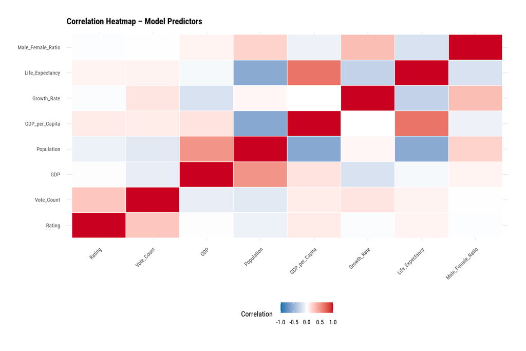

```r
# Source: OpenAI
# Model: GPT-5
predictor_vars <- intersect(model_features, numerical_vars)

if (length(predictor_vars) > 1) {
  predictor_numeric <- model_frame %>%
    select(all_of(predictor_vars)) %>%
    mutate(across(everything(), as.numeric)) %>%
    drop_na()

  predictor_corr <- cor(predictor_numeric, use = "pairwise.complete.obs")
  predictor_corr_df <- as.data.frame(as.table(predictor_corr))

  ggplot(predictor_corr_df, aes(x = Var1, y = Var2, fill = Freq)) +
    geom_tile(colour = "white") +
    scale_fill_gradient2(
      low = "#0571b0",
      mid = "white",
      high = "#ca0020",
      midpoint = 0,
      limits = c(-1, 1)
    ) +
    labs(
      title = "Correlation Heatmap – Model Predictors",
      x = NULL,
      y = NULL,
      fill = "Correlation"
    ) +
    theme(
      axis.text.x = element_text(angle = 45, hjust = 1)
    )
}
```

#### Explanation of the Correlation Heatmap

The **correlation heatmap** visually represents the relationships between different predictor variables in the dataset, showing the strength and direction of their linear relationships. The colors indicate the degree of correlation, with **red** indicating a positive correlation and **blue** indicating a negative correlation.

#### 1. **Understanding the Color Scale**:

- The **color scale** at the bottom shows the correlation values ranging from **-1** (strong negative correlation) to **1** (strong positive correlation).
- A value of **0** indicates no correlation between two variables.

#### 3. **Purpose of the Heatmap**:

- The heatmap provides a visual summary of the correlation structure in the dataset, helping to identify highly correlated predictors, which can guide decisions on feature selection, potential multicollinearity issues, or the need for further transformation of variables.

### 5.8.2 Remove Highly Coorelated Features

```r
# Source: OpenAI
# Model: GPT-5
if (length(numerical_vars) > 1) {
  corr_matrix <- cor(
    model_frame %>% select(all_of(numerical_vars)),
    use = "pairwise.complete.obs"
  )
  high_corr <- findCorrelation(corr_matrix, cutoff = 0.9, names = TRUE)
  if (length(high_corr) > 0) {
    cat(
      "Removing highly correlated numerical variables (>|0.9|):",
      paste(high_corr, collapse = ", "), "\n"
    )
    model_frame <- model_frame %>% select(-all_of(high_corr))
    numerical_vars <- setdiff(numerical_vars, high_corr)
  }
}
```

### Explanation of the Code: Removing Highly Correlated Numerical Variables

1. **Checking if there are multiple numerical variables**:
   - The code `if (length(numerical_vars) > 1)` ensures that there is more than one numerical variable in the dataset before attempting to calculate the correlation matrix. If only one or no numerical variables exist, the correlation matrix calculation and feature removal will not proceed.
2. **Creating a Correlation Matrix**:
   - The line `corr_matrix <- cor(model_frame %>% select(all_of(numerical_vars)), use = "pairwise.complete.obs")` computes the **correlation matrix** for all numerical variables in `model_frame`.
     - The `cor()` function calculates pairwise correlations between the numerical variables using the **Pearson correlation coefficient**.
     - `use = "pairwise.complete.obs"` ensures that only complete pairs of values are used in the correlation calculation, meaning missing values are ignored for each pair of variables.
3. **Identifying Highly Correlated Variables**:
   - `high_corr <- findCorrelation(corr_matrix, cutoff = 0.9, names = TRUE)` identifies the **highly correlated variables** (with a correlation greater than 0.9) in the correlation matrix.
     - The `findCorrelation()` function from the **caret** package returns the names of variables that are **highly correlated** with others. These variables have a correlation coefficient of greater than **0.9** in absolute value.
     - The `cutoff = 0.9` argument sets the threshold for high correlation. You can adjust this cutoff to identify weaker or stronger correlations.
4. **Removing Highly Correlated Variables**:
   - `if (length(high_corr) > 0)` checks if there are any highly correlated variables. If such variables are found, the following steps are taken:
     - The **`cat()`** function is used to print the names of the **highly correlated variables** that will be removed.
     - `model_frame <- model_frame %>% select(-all_of(high_corr))` removes these highly correlated variables from the `model_frame` dataset.
     - `numerical_vars <- setdiff(numerical_vars, high_corr)` updates the `numerical_vars` list by removing the names of the highly correlated variables, ensuring that the correlation analysis and feature selection process stays consistent.
5. **Purpose**:
   - **Feature Selection**: This process is part of feature selection to reduce multicollinearity. When numerical variables are highly correlated (i.e., when two or more variables provide similar information), one of them can be removed to avoid redundancy. This helps to improve the model’s performance and prevent issues such as overfitting.
6. **Reasoning Behind Removing Highly Correlated Variables**:
   - Highly correlated features can cause problems in models, especially linear models, by inflating standard errors and making the model less interpretable. Removing these variables helps to ensure that the model doesn’t rely too heavily on redundant predictors, which can improve model accuracy and stability.

## 5.9 **Single Variable AUC Analysis**

**AUC (Area Under the Curve)** refers to the **Area Under the Receiver Operating Characteristic (ROC) Curve** and is a performance measurement for classification models, particularly in binary classification problems.

#### 1. **Concept**:

- The **ROC Curve** is a graphical representation of the **True Positive Rate (TPR)** against the **False Positive Rate (FPR)** at various threshold settings.
- **True Positive Rate (TPR)**, also known as **Recall**, is the proportion of actual positives correctly identified by the model:
  $$TPR = \frac{TP}{TP + FN}$$
  where $TP$ is the number of true positives, and $FN$ is the number of false negatives.
- **False Positive Rate (FPR)** is the proportion of actual negatives incorrectly identified as positives:
  $$FPR = \frac{FP}{FP + TN}$$
  where $FP$ is the number of false positives, and $TN$ is the number of true negatives.
- The **AUC** is the area under this ROC curve, and it provides a single value that summarizes the performance of the classification model.

#### 2. **Interpretation**:

- **AUC = 1**: Perfect model. The model is able to perfectly distinguish between positive and negative classes.
- **AUC = 0.5**: No discrimination. The model’s performance is no better than random guessing.
- **AUC < 0.5**: Worse than random. The model is performing worse than random chance, essentially making inverse predictions.

A higher AUC value indicates better model performance, meaning the model is more capable of distinguishing between the positive and negative classes.

#### 3. **AUC as a Performance Metric**:

- AUC is often used in situations where **class imbalance** exists or where we care about the overall ability of the model to rank predictions rather than just achieving high accuracy.
- It is a robust metric as it evaluates the model performance across all possible classification thresholds.

#### 4. **Advantages**:

- **Threshold-independent**: AUC evaluates model performance without the need to choose a specific classification threshold.
- **Class imbalance sensitivity**: It provides a useful measure even when the data is highly imbalanced.

#### 5. **Purpose**:

- **AUC** is widely used to evaluate classification models, especially when it’s essential to assess the model’s ability to rank instances and distinguish between classes across a range of thresholds.

### Define Helper Functions

`evaluate_single_variable`

```r
# Source: OpenAI
# Model: GPT-5
evaluate_single_variable <- function(var_name, train_data, test_data) {
  formula <- if (grepl(" ", var_name)) {
    as.formula(paste("High_Revenue ~ `", var_name, "`", sep = ""))
  } else {
    as.formula(paste("High_Revenue ~", var_name))
  }

  tryCatch({
    model <- glm(formula, data = train_data, family = binomial())
    pred_prob <- predict(model, test_data, type = "response")
    if (length(unique(test_data$High_Revenue)) == 2) {
      auc(roc(test_data$High_Revenue, pred_prob))
    } else {
      NA_real_
    }
  }, error = function(e) {
    message("Error with variable ", var_name, ": ", e$message)
    NA_real_
  })
}
```

#### Explanation of the `evaluate_single_variable` Function

The `evaluate_single_variable` function evaluates the predictive power of a single feature (variable) by fitting a logistic regression model and calculating the **AUC (Area Under the Curve)** on a given test dataset.

#### Input Parameters:

- **`var_name`**: The name of the feature (variable) being evaluated. This variable will be used to predict the target variable `High_Revenue` in the logistic regression model.
- **`train_data`**: The dataset used for training the logistic regression model. It should contain both the feature and the target variable (`High_Revenue`).
- **`test_data`**: The dataset used for testing the model. It should contain the feature being evaluated and the target variable (`High_Revenue`), and it will be used to calculate the model’s **AUC**.

#### Function Steps:

1. **Creating the Formula**:
   - The formula for the logistic regression model is dynamically created using `as.formula()`. The formula will be in the form of:
     - `"High_Revenue ~ <var_name>"`, where `<var_name>` is the feature being evaluated.
   - If the feature name contains spaces (e.g., `GDP per Capita`), it is wrapped in backticks (`` ` ``) to handle the spaces correctly.
2. **Fitting the Logistic Regression Model**:
   - The model is fitted using `glm(formula, data = train_data, family = binomial())`, which specifies a **binomial family** for logistic regression. This models the probability of a binary outcome (whether a movie is classified as “High” or “Low” revenue).
   - The logistic regression model is trained on the `train_data` dataset.
3. **Making Predictions**:
   - `pred_prob <- predict(model, test_data, type = "response")`:
     - The `predict()` function is used to generate predicted probabilities on the `test_data` dataset. The `type = "response"` argument ensures that the output is in the form of probabilities (ranging from 0 to 1), representing the likelihood that each movie is classified as “High” revenue.
4. **Calculating AUC**:
   - The **AUC (Area Under the Curve)** is calculated using the **ROC (Receiver Operating Characteristic) curve**. The `roc()` function from the **pROC** package is used to compute the ROC curve, and `auc()` computes the area under the curve.
   - The `roc()` function compares the predicted probabilities (`pred_prob`) with the actual values of `High_Revenue` in the test dataset (`test_data$High_Revenue`).
   - If the test dataset contains exactly two unique classes (i.e., the “High” and “Low” revenue classes), the **AUC** is computed. Otherwise, `NA_real_` is returned.
5. **Error Handling**:
   - The entire process is wrapped in a `tryCatch()` block to handle any potential errors that may arise during model fitting or evaluation. If an error occurs (e.g., due to issues with the data), an error message is printed, and `NA_real_` is returned.

#### Output:

- The function returns the **AUC score** for the logistic regression model using the specified feature. If there are issues with the model or data, `NA_real_` is returned.

#### Reasoning Behind the Process:

- **Why Use Logistic Regression?**
  - Logistic regression is well-suited for binary classification tasks, like predicting whether a movie has high or low revenue. It provides probabilities (rather than just class labels) and can model the relationship between a predictor variable and the binary outcome.
- **Why Calculate AUC?**
  - **AUC** is a robust metric for evaluating classification models, especially in imbalanced datasets. It measures the model’s ability to discriminate between the two classes, independent of the decision threshold.

### 5.9.1 **Training and Evaluating AUC for Single Variables**

```r
# Source: OpenAI
# Model: GPT-5
set.seed(4009)
train_index_sv <- createDataPartition(model_frame$High_Revenue, p = 0.7, list = FALSE)
train_data_sv <- model_frame[train_index_sv, ]
test_data_sv <- model_frame[-train_index_sv, ]

exclude_vars <- intersect(c("Relative_Revenue", "Total_Revenue"), numerical_vars)

auc_results <- data.frame(Variable = character(), AUC = numeric())

for (var in setdiff(numerical_vars, exclude_vars)) {
  auc_val <- evaluate_single_variable(var, train_data_sv, test_data_sv)
  if (!is.na(auc_val)) {
    auc_results <- rbind(auc_results, data.frame(Variable = var, AUC = auc_val))
  }
}

auc_results <- auc_results %>% arrange(desc(AUC))
```

#### Explanation of the Code: Training and Evaluating AUC for Single Variables

1. **Setting the Random Seed**:
   - `set.seed(4009)` ensures that the random sampling for splitting the data is reproducible. This means that every time the code runs, the same random split will be applied to the dataset.
2. **Splitting the Data into Training and Test Sets**:
   - `train_index_sv <- createDataPartition(model_frame$High_Revenue, p = 0.7, list = FALSE)`:
     - This creates a partition of the data where **70%** of the data is used for training, and **30%** is used for testing. The partition is done **stratified by the target variable (`High_Revenue`)**, so that the distribution of the “High” and “Low” revenue classes is preserved in both the training and test sets.
     - `createDataPartition()` is a function from the **caret** package used for creating stratified splits.
   - `train_data_sv <- model_frame[train_index_sv, ]`:
     - This subsets the original dataset, `model_frame`, to get the training data based on the `train_index_sv` indices.
   - `test_data_sv <- model_frame[-train_index_sv, ]`:
     - This creates the test dataset by selecting the rows that are **not included** in the training set (the complement of `train_index_sv`).
3. **Excluding Certain Variables**:
   - `exclude_vars <- intersect(c("Relative_Revenue", "Total_Revenue"), numerical_vars)`:
     - This line identifies which variables in the dataset need to be **excluded from the analysis**. In this case, `Relative_Revenue` and `Total_Revenue` are excluded, as they might be highly correlated or redundant with other features in the dataset.
     - The `intersect()` function is used to ensure that the excluded variables are part of the `numerical_vars` list.
4. **Initializing an Empty Data Frame for AUC Results**:
   - `auc_results <- data.frame(Variable = character(), AUC = numeric())`:
     - This initializes an empty data frame to store the **AUC** results for each numerical variable being evaluated. The data frame will have two columns:
       - **Variable**: The name of the variable being evaluated.
       - **AUC**: The **Area Under the Curve** score for that variable.
5. **Looping Over Numerical Variables (Excluding Certain Variables)**:
   - The `for` loop iterates over the **numerical variables** that are not in the `exclude_vars` list. The `setdiff(numerical_vars, exclude_vars)` ensures that the excluded variables (`Relative_Revenue` and `Total_Revenue`) are skipped in the evaluation.
   - For each variable in the loop:
     - `auc_val <- evaluate_single_variable(var, train_data_sv, test_data_sv)`:
       - This function (`evaluate_single_variable`) is assumed to be a custom function that computes the **AUC** for the given variable (`var`) in the training and test datasets. This function likely fits a model using the specified feature and evaluates the **AUC** score based on the true outcome (`High_Revenue`) and predicted probabilities.
     - If the computed **AUC** is not `NA`, the result is appended to the `auc_results` data frame using `rbind()`.
6. **Sorting the AUC Results**:
   - `auc_results <- auc_results %>% arrange(desc(AUC))`:
     - This sorts the `auc_results` data frame in descending order of **AUC**, so that the feature with the highest **AUC** is at the top, indicating that it is the most predictive of the target variable (`High_Revenue`).

#### Purpose of the Code:

- This code is used to evaluate the **predictive power** of each **numerical variable** in relation to the **“High_Revenue”** target variable. By calculating the **AUC** for each feature, it helps to identify which variables contribute the most to predicting movie revenue classification.
- **AUC** is a valuable metric for evaluating classification models, as it measures how well the model distinguishes between the two classes (in this case, “High” and “Low” revenue).

#### Reasoning Behind the Process:

- **Why Exclude Certain Variables?**
  - Excluding highly correlated or redundant features, such as `Relative_Revenue` and `Total_Revenue`, prevents overfitting and ensures that the model doesn’t rely too heavily on features that provide similar information.

### 5.9.2 **Plotting the AUC Results Using a Bar Chart**

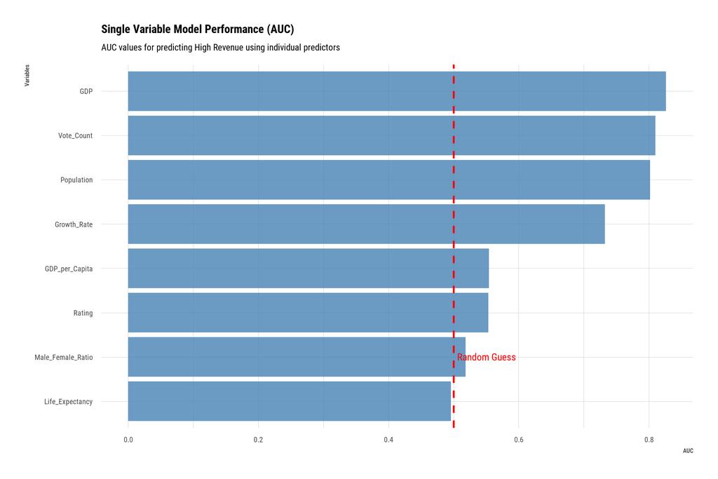

```r
ggplot(auc_results, aes(x = reorder(Variable, AUC), y = AUC)) +
  geom_col(fill = "steelblue", alpha = 0.8) +
  coord_flip() +
  labs(
    title = "Single Variable Model Performance (AUC)",
    subtitle = "AUC values for predicting High Revenue using individual predictors",
    x = "Variables",
    y = "AUC"
  ) +
  geom_hline(yintercept = 0.5, linetype = "dashed", colour = "red") +
  annotate("text", x = 2, y = 0.55, label = "Random Guess", colour = "red")
```

#### Explanation of the Visual: Single Variable Model Performance (AUC)

This visualization displays the **AUC (Area Under the Curve)** values for individual features used to predict **High_Revenue** classification (whether a movie has “High” or “Low” revenue). The **AUC** values represent the model’s ability to discriminate between the two classes (“High” and “Low” revenue).

#### Key Elements of the Plot:

1. **Bar Plot Representation**:
   - Each **horizontal bar** represents one feature (variable) used in the logistic regression model.
   - The **length of the bar** corresponds to the **AUC score** for that feature. A longer bar indicates a higher AUC, meaning the feature has a stronger ability to distinguish between “High” and “Low” revenue.
2. **Variables**:
   - The **variables** evaluated are:
     - **GDP**
     - **Vote_Count**
     - **Population**
     - **Growth_Rate**
     - **GDP_per_Capita**
     - **Rating**
     - **Male_Female_Ratio**
     - **Life_Expectancy**
   - These are the individual predictors being assessed for their ability to predict the target variable, **High_Revenue**.
3. **AUC**:
   - **AUC** values range from **0 to 1**, where:
     - **0.5** represents a **random guess** (the model is no better than random chance).
     - A higher **AUC** indicates better model performance and a stronger relationship between the feature and the outcome.
4. **“Random Guess” Line**:
   - A **red dashed line** is drawn at **AUC = 0.5**, which represents the baseline for a **random guess**.
   - Features with **AUC values above 0.5** are better than random guessing, while features with values **below 0.5** would indicate worse-than-random performance.

#### Key Insights:

- **Top Performing Variables**: The **GDP**, **Vote_Count**, and **Population** features have **AUC values above 0.7**, indicating they are strong predictors of **High_Revenue**.
- **Weak Performing Variables**: **Life_Expectancy** and **Male_Female_Ratio** have lower **AUC values**, closer to **0.5**, meaning they contribute less to the model’s ability to differentiate between “High” and “Low” revenue movies.

#### Reasoning Behind AUC:

- Higher **AUC** values mean the feature is better at distinguishing between the two classes, while lower values suggest weaker predictive power.

### 5.9.3 **Top Variables Based on AUC**

**Filtering Variables with AUC > 0.5**: - The line `top_variables <- auc_results %>% filter(AUC > 0.5) %>% pull(Variable)` performs the following steps: - **`filter(AUC > 0.5)`**: This filters the `auc_results` data frame to keep only the variables that have an **AUC** greater than **0.5**. This ensures that we select the features that have better-than-random performance in predicting the target variable (**High_Revenue**). - **`pull(Variable)`**: This extracts the **Variable** column from the filtered data, resulting in a vector of variable names that have **AUC > 0.5**.

```r
top_variables <- auc_results %>%
  filter(AUC > 0.5) %>%
  pull(Variable)
cat("\nTop variables selected (AUC > 0.5):",
    paste(top_variables, collapse = ", "), "\n")
```

```
##
## Top variables selected (AUC > 0.5): GDP, Vote_Count, Population, Growth_Rate, GDP_per_Capita, Rating, Male_Female_Ratio
```

#### Explanation of the Output: Top Variables Selected Based on AUC

The output indicates that the following variables have been selected based on their **AUC** scores greater than **0.5**, meaning they are useful for predicting the **“High_Revenue”** target variable:

- **GDP**
- **Vote_Count**
- **Population**
- **Growth_Rate**
- **GDP_per_Capita**
- **Rating**
- **Male_Female_Ratio**

#### Key Insights:

1. **Predictive Features**: These variables all have **AUC > 0.5**, indicating they have **predictive value** in distinguishing between “High” and “Low” revenue movies. Each of these features contributes to the model’s ability to classify movies as either “High” or “Low” revenue.
2. **AUC as a Measure**: **AUC** values greater than **0.5** show that the features are better than random guessing in distinguishing the two classes. The closer the AUC is to **1**, the better the feature is at making accurate predictions.
3. **Importance of Features**:
   - Variables such as **GDP**, **Vote_Count**, and **Population** seem to have higher AUC values, suggesting that they have a stronger relationship with predicting “High” revenue.
   - Features like **Rating** and **Growth_Rate** have slightly lower AUC values, but they still contribute useful information for predicting revenue.

#### Next Steps:

- **Modeling**: With these top variables selected, you can proceed to build a more complex model (e.g., **logistic regression**, **random forest**, etc.) using these predictors.
- **Feature Selection**: The selected variables can be used in the final model, as they show good predictive capability based on their AUC values. Features with lower AUC values could be excluded to reduce model complexity and overfitting.

## 5.10 **Feature Selection Using Information Gain**

**Information Gain (IG)** is a measure used in decision trees and other machine learning algorithms to evaluate the effectiveness of a feature in classifying data. It quantifies how much **information** is gained about the target variable by knowing the value of a feature.

#### 1. **Concept**:

- Information Gain is based on the concept of **entropy**, which measures the uncertainty or disorder in a dataset.
- **Entropy** for a dataset can be calculated as:
  $$H(S) = -\sum p_i \log_2(p_i)$$
  where $p_i$ is the probability of class $i$ in the dataset.
- **Information Gain** is the reduction in **entropy** achieved by splitting the data based on a particular feature. It is calculated as the difference between the entropy of the dataset before and after the split:
  $$IG(S, A) = H(S) - \sum \frac{|S_v|}{|S|} H(S_v)$$
  where:
  - $S$ is the original dataset.
  - $A$ is the feature under consideration.
  - $S_v$ represents the subsets of the data created by splitting on feature $A$.
  - $H(S_v)$ is the entropy of each subset.
  - $|S_v| / |S|$ is the proportion of elements in subset $S_v$.

#### 2. **Interpretation**:

- **Higher Information Gain** means that the feature does a better job of separating the data, as it reduces uncertainty more effectively.
- **Lower Information Gain** suggests that the feature doesn’t provide much new information about the target variable, and it might be less useful for classification.

#### 3. **Usage in Decision Trees**:

- Information Gain is used in decision tree algorithms (like **ID3** and **C4.5**) to decide which feature to use at each step of the tree-building process.
- At each node, the feature with the **highest Information Gain** is selected to split the data, ensuring that the tree grows in a way that maximizes classification accuracy.

#### 4. **Purpose**:

- Information Gain is a key concept in feature selection and data splitting, enabling machine learning algorithms to identify the most informative features for predicting outcomes or classifying data.

### 5.10.1 **Defining the Info Gain Pipelines and Observing Results**

```r
feature_selection_data <- model_frame

info_gain <- information_gain(High_Revenue ~ ., data = feature_selection_data) %>%
  arrange(desc(importance))
print(info_gain)
```

```
##          attributes  importance
## 1               GDP 0.167641675
## 2        Population 0.157995761
## 3        Vote_Count 0.147306728
## 4 Male_Female_Ratio 0.145720824
## 5       Growth_Rate 0.122752853
## 6    GDP_per_Capita 0.072219898
## 7   Life_Expectancy 0.068736334
## 8            Rating 0.004136976
```

### Purpose:

- **Information Gain** is a feature selection technique that quantifies the reduction in uncertainty (entropy) when a feature is used to predict the target variable. The higher the information gain, the more predictive the feature is.
- This approach helps identify which features are most important for predicting **High_Revenue** and aids in the **dimensionality reduction** process by removing less important features.

#### Printing the Information Gain Results

```r
print(info_gain)
```

```
##          attributes  importance
## 1               GDP 0.167641675
## 2        Population 0.157995761
## 3        Vote_Count 0.147306728
## 4 Male_Female_Ratio 0.145720824
## 5       Growth_Rate 0.122752853
## 6    GDP_per_Capita 0.072219898
## 7   Life_Expectancy 0.068736334
## 8            Rating 0.004136976
```

### Explanation of the Information Gain Results

The output of the **Information Gain** analysis shows the importance of each feature in predicting the target variable, **High_Revenue**. The higher the **importance** value, the more informative the feature is in reducing the uncertainty about the target variable.

#### Insights:

- **Top Features**: **GDP**, **Population**, and **Vote_Count** are the most influential variables for predicting movie revenue. These features should be prioritized in the modeling process as they provide the most information about whether a movie will have high or low revenue.
- **Lower Importance Features**: **Life_Expectancy** and **Rating** have low importance, suggesting that they might be less useful predictors in the model. You might consider removing or down-weighting these variables to simplify the model without sacrificing predictive performance.

### 5.10.2 **Building Feature Set Based on Information Gain**

```r
selected_candidates <- info_gain %>%
  filter(importance > 0.01)
num_ig <- min(6, nrow(selected_candidates))
if (num_ig > 0) {
  selected_features_ig <- selected_candidates$attributes[seq_len(num_ig)]
} else {
  selected_features_ig <- info_gain$attributes[seq_len(min(4, nrow(info_gain)))]
}
features_info_gain <- intersect(selected_features_ig, names(model_frame))
if (length(features_info_gain) == 0) {
  features_info_gain <- intersect(info_gain$attributes, names(model_frame))
}
```

#### Explanation of the Code: Selecting Features Based on Information Gain

1. **Filtering Features Based on Importance**:
   - `selected_candidates <- info_gain %>% filter(importance > 0.01)`:
     - This line filters the **information gain results** (`info_gain`) to keep only those features that have an **importance** greater than **0.01**. Features with an importance lower than this threshold are considered less useful for predicting the target variable (`High_Revenue`), so they are excluded from further analysis.
2. **Selecting the Top Features**:
   - `num_ig <- min(6, nrow(selected_candidates))`:
     - This line determines how many features to select from the `selected_candidates` dataset. It selects a maximum of **6** features, but if there are fewer than 6 features with importance greater than **0.01**, it will select all available features.
   - `if (num_ig > 0) { selected_features_ig <- selected_candidates$attributes[seq_len(num_ig)] } else { selected_features_ig <- info_gain$attributes[seq_len(min(4, nrow(info_gain)))] }`:
     - If there are any features with importance greater than **0.01**, the top **`num_ig`** features are selected. These features are stored in the `selected_features_ig` vector.
     - If no features have an importance greater than **0.01**, the code falls back to selecting the top **4** features from the original `info_gain` results.
3. **Ensuring the Selected Features are in the Dataset**:
   - `features_info_gain <- intersect(selected_features_ig, names(model_frame))`:
     - This line ensures that the selected features are present in the `model_frame` dataset. It keeps only those features from `selected_features_ig` that actually exist in the `model_frame` dataset.
4. **Handling the Case Where No Features are Selected**:
   - `if (length(features_info_gain) == 0) { features_info_gain <- intersect(info_gain$attributes, names(model_frame)) }`:
     - If no features were selected (i.e., `features_info_gain` is empty), the code will fall back to selecting the top features from the `info_gain` results that are present in the `model_frame` dataset.

#### Purpose of the Code:

- This code performs **feature selection** based on **information gain** to identify the most important features for predicting **High_Revenue**. It selects the top features that have **significant information gain** values (greater than 0.01) and ensures that the selected features are present in the dataset.

### 5.10.3 Printing Final Info Gain Feature Set

```r
cat("Info Gain feature set:",
    paste(features_info_gain, collapse = ", "), "\n")
```

```
## Info Gain feature set: GDP, Population, Vote_Count, Male_Female_Ratio, Growth_Rate, GDP_per_Capita
```

#### Explanation of the Information Gain Feature Set

The **Information Gain** feature selection process has identified the following variables as the most important for predicting whether a movie will have **High_Revenue**:

- **GDP**
- **Population**
- **Vote_Count**
- **Male_Female_Ratio**
- **Growth_Rate**
- **GDP_per_Capita**

These features have the highest **information gain** values, indicating that they provide the most valuable information for predicting the target variable, **High_Revenue**.

#### Key Insights:

1. **GDP**: This is the most important feature for predicting high revenue, indicating that the **economic strength of a country** plays a major role in a movie’s box office success.
2. **Population**: A large population is likely correlated with higher box office revenue, as it reflects a larger potential audience for the movie.
3. **Vote_Count**: This feature represents the number of votes a movie receives, which is a strong indicator of its popularity and audience engagement, directly impacting its revenue.
4. **Male_Female_Ratio**: The gender distribution in a country might influence movie preferences and demand, affecting box office revenue.
5. **Growth_Rate**: The annual growth rate of a country’s population reflects the **future audience size**, which could contribute to long-term revenue potential for movies.
6. **GDP_per_Capita**: This feature indicates the **economic prosperity per individual** in a country, which may affect consumers’ ability to spend on entertainment, including movie tickets.